# Catalog v5.1: seismicity, fault surfaces v1 and swarms, region by region

Cascadia OBS ensemble catalog v5.1 (NonLinLoc in model v0.3.1, 2010-2016). Piece "interp", 2026-11-25; revised the same day after an independent review. Private working product, not peer reviewed. Inputs: magnitudes (branch analysis/v51-mag, cd0334d6), fault surfaces v1 (analysis/v51-faults, 6ebe0230), clustering (analysis/v51-clusters, f904659b), all three revised after their reviews; the verifiers' tables on /wd1; the waveform review of four v5.1 location problems (/wd1/mdenolle_data/catalog_v5/v5.1_review). Code: workflow/06_analysis/v51_interp_*.py on analysis/v51-interp.

## Summary

- **Inputs.** Catalog v5.1 (172,342 rows; 623 rows without a hypocentre and 3,313 flagged non-earthquakes are left out of every spatial statistic, leaving 168,406 located earthquakes), the revised v5.1 magnitudes, clustering and fault surfaces v1 (each fixed after its own review), the v4-era science report and v0 literature matches, the depth-literature report and the waveform review of four v5.1 location problems (P1-P4). These products will be redone on catalog v6.0 (D-B079); model v0.4.0 is adopted (D-B082) and v0.4.1 is being built (D-B083).
- **Where v5.1 depths can be interpreted.** Axial (81% of tier A-B within 2 km of the seafloor against 90% published; no pile-up at the 3 km model node), Mount St. Helens shallow events (+0.5 to +0.8 km against Hirao et al. 2025), Puget/Georgia (crust at a median 19.5 km against 15-25 km), the Fortuna cluster (19.0 km against 17-23 km) and the Gorda interior near stations (8.3 km below the seafloor, inside the 9.5-15 km thermal limit).
- **Where they cannot.** Endeavour, Explorer (seaward median 44 km bsl against at most 22 km published; v4 9 km), the Juan de Fuca ridge (41% floor_limited), the Gorda plate away from stations (biased_deep, 22 km below the seafloor; +7 to +9 km against ANSS), the Blanco outside the 2012-13 X9 year and on the Blanco Ridge and Gorda Depression (+3 to +6 km against Lange et al. 2026), Mendocino in absolute terms (+3.6 km against NCSN, v4 +1.5 km), the 351 events deeper than 30 km under Mount St. Helens (review P1), the 2012 Brookings swarm (review P2) and 659 Cascades events deeper than 30 km in all.
- **Catalog problems.** (1) Deep events under Mount St. Helens: the review (P1) found a weekly artificial signal on analog UW channels and calls the deep events likely false. Here the deep events follow local time: 71 of them fall on 51 Wednesdays between 11:30 and 13:00 Pacific time, in standard and daylight time alike, and the review's 19:14-19:21 UTC detections are all on daylight-time Wednesdays, so a flag rule must use local time; 280 of the 351 deep events fall outside that window. (2) Depths spike at integer km (1 km grid lattice; strongest at Blanco 12 km), not at the model nodes as such; the Axial "3 km node pile-up" of the first build is withdrawn. (3) Blast-like onshore events: about 1,130 of the 2,094 Puget/Georgia and Other onshore events within 1 km of the surface, and about 2,470 above 8 km, by their weekday-daytime excess. (4) The 2012 Brookings swarm at 52 km, about 42 km below the slab top (about 10 km there); the review (P2) shows a second S-P solution near 7-9 km.
- **Faults.** Of the 130 non-strand v1 surfaces, 38 are recovered on an 80% subsample, 12 after one error perturbation and 10 of 116 on tiers A-B; the 12 Blanco strands have no recovery test and 5 of them, including the two long West Blanco Depression strands, are unstable under re-detection, as are the Mendocino slab layers. The surfaces that are both stable and recovered are mostly local: SHZ (v1_ON001), Western Rainier Seismic Zone, Skipjack Island, Garberville, Springfield, Salmon Inlet, the Oregon shelf clusters and the Explorer traces (map only); the Fortuna layer (v1_MT001) is recovered but unstable. The Cascadia Depression N-S faults of v0 are not recovered because of detection order, not because of the relocation.
- **Clustering.** The ordering by setting holds where it is robust: the West Blanco Depression is swarm-rich (45% of events above Mc in swarms; the BL box as a whole has a shuffled/real link ratio of 0.39, 0.62 within the month, and no WBD-only null test was run), the Mendocino triple junction is burst-like with low productivity (28% swarms among families of 5 or more), and the forearc and Puget are background-dominated. The Axial result is not robust (background 38-82% depending on the variant; 75% of its links appear in shuffled catalogs). Within-month shuffles reproduce 62%-92% of the links in every box.
- **Magnitudes.** The phase19 inversion is not converged (v4.1 and v5.1); converged, offshore ML would drop by 0.28-0.68 in Blanco, JdF, Gorda, Mendocino and the forearc, and the v5.1 - v4.1 offshore change would shrink from +0.08 to +0.20 to -0.001 to +0.042. Production M is unchanged (PI decision), so offshore Mc and magnitudes here carry this.
- **Swarms.** Most swarms are as small as the location errors (median 90% radius 2.2 km against a 2.0 km horizontal error); 15 of 129 are resolvable. Of the 67 resolvable families, 4 pass the permutation migration test (p < 0.01; about 0.7 expected by chance). Two survive a Bonferroni correction (p < 0.00075): the 2012-02-04 Explorer sequence, a second cluster 15 km NNE activated 9-12 days after the mainshock rather than a continuous front, and Puget family 675, a 0.004 km/day drift over three years. The two small swarms (Gorda 2013-11-13, p = 0.0045; Cascades 2012-09-10, p = 0.002, 0.0004 in the verifier's run) are candidates only. Two v4 migration results are gone (2013-05-20 Escanaba swarm, 10 km/day in v4; the 2012-11 Explorer sequence).
- **v4 interpretations withdrawn or changed:** 25 statements, listed in the last table.

**How to read the numbers.** Depths are km below sea level (bsl) unless written "below the seafloor" or "below the surface" (depth + surface_km). "depth_good" = tier A-C, depth_quality ok, not floor_limited, far_only or deep_pass (98,204 events); Endeavour, Explorer and the JdF ridge have none. Regions are the catalog's `region` labels (set from the v4 epicentre); the clustering uses its nine boxes (AX, EN, BL, GO, MT, WA, OR, PU, ON) and the fault surfaces their v0 boxes, so box-level numbers are quoted with the box name. v4 depths have an unconfirmed datum: read as km bsl, 4.8-70% of them (by region) plot above the ground or seafloor, so v4-v5.1 depth changes offshore mix the relocation with the datum. The magnitude, fault and clustering pieces were revised after their own reviews; this report reads the revised products (commits in the header) and corrects its own first build where the interp review asked (Axial node pile-up withdrawn; integer-km depth spikes; Mount St. Helens signal in local time; blast population sized by its excess; Brookings slab depth; migration multiple testing).

**Context.** Catalog v5.1 is located in model v0.3.1. The PI has adopted model v0.4.0 (v0.3.1 re-inverted with the re-timed picks, D-B082); v0.4.1, with a surface floor in the inversion (D-B083), is being built. Catalog v6.0 (D-B079, NonLinLoc with SSST station terms) will supersede v5.1, and these products will be redone on it. Waveform review reports exist for four v5.1 location problems (/wd1/mdenolle_data/catalog_v5/v5.1_review/index.html): P1 Mount St. Helens deep events (likely false events from a weekly artificial signal on analog UW channels), P2 the 2012 Brookings swarm (two S-P depth solutions; NonLinLoc took the deep one), P3 events with ComCat moment tensors (v5.1 a median 13.7 km deeper than ComCat) and P4 far_only events (moved from near the surface in v4 to 44-64 km) and deep-pass events. Human review of these sets is pending.

## Margin-wide comparison with v4

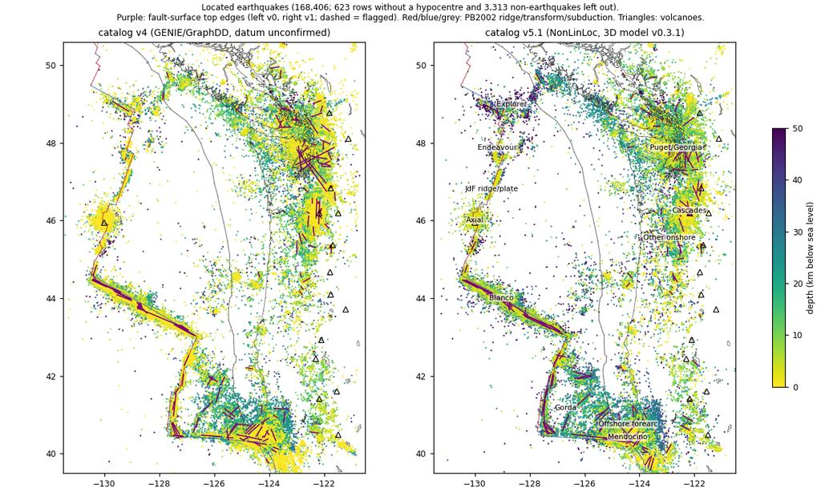

Located earthquakes of v4 (left) and v5.1 (right) coloured by depth, with the v0 and v1 fault-surface top edges.

### Locations

The relocation moved epicentres by a median 1-8 km depending on the region (Explorer most) and depths by a median of +0.7 km (Puget/Georgia) to +25 km (Explorer): every region is deeper at the median, partly because v4 depths were biased shallow. Onshore and at Mendocino the changes are small; at Explorer, Endeavour and in the Gorda interior the v5.1 depths are deeper than any published constraint. Structure is not sharper in v5.1 except at Axial, where the apparent sharpening comes partly from the oct-tree lattice: the median distance to the fifth neighbour of depth_good events changes by 11% or less elsewhere, and the depth interquartile range grows on the Blanco (7.2 to 9.0 km) and at Mendocino (6.0 to 9.1 km) and shrinks in Gorda (16 to 11 km).

| region | located | no hypocentre | non-eq | % A | % D | floor_lim | far_only | deep_pass | depth_good | v4 depth med | v5.1 depth med | v5.1 below surface | good: v4 med | good: v5.1 med | dh med km | dz med km | sig_z med | nearest sta km | v4 % above surface |
| --- | --- | --- | --- | --- | --- | --- | --- | --- | --- | --- | --- | --- | --- | --- | --- | --- | --- | --- | --- |
| Axial | 26726 | 5 | 0 | 14.6 | 20.2 | 1562 | 0 | 3 | 20487 | 0.3 | 3.3 | 1.8 | 0.2 | 3.2 | 3.2 | 3.0 | 1.8 | 1.0 | 69.7 |
| Endeavour | 178 | 1 | 0 | 0.0 | 74.2 | 47 | 0 | 1 | 0 | 1.4 | 10.8 | 8.2 |  |  | 5.6 | 6.9 | 14.0 | 29.2 | 54.5 |
| Explorer | 1514 | 9 | 0 | 0.0 | 34.5 | 50 | 24 | 27 | 0 | 9.0 | 40.5 | 38.3 |  |  | 7.8 | 25.3 | 10.6 | 74.9 | 26.0 |
| JdF ridge/plate | 2843 | 8 | 0 | 0.0 | 65.5 | 1173 | 11 | 15 | 0 | 5.1 | 3.3 | 0.8 |  |  | 4.5 | 3.3 | 13.3 | 34.5 | 43.3 |
| Blanco | 42349 | 36 | 0 | 1.7 | 22.0 | 1046 | 286 | 13 | 17116 | 9.2 | 9.3 | 6.3 | 8.3 | 8.9 | 1.6 | 4.3 | 7.0 | 23.3 | 20.6 |
| Gorda | 11352 | 28 | 0 | 3.9 | 24.7 | 345 | 214 | 15 | 1506 | 21.2 | 24.7 | 21.7 | 1.3 | 15.9 | 3.5 | 4.7 | 6.6 | 30.8 | 22.5 |
| Mendocino | 24608 | 36 | 0 | 21.9 | 27.5 | 448 | 50 | 25 | 17690 | 21.1 | 23.4 | 23.0 | 21.5 | 24.0 | 1.8 | 2.7 | 2.9 | 14.0 | 4.8 |
| Offshore forearc | 15398 | 24 | 1584 | 10.5 | 28.2 | 442 | 30 | 21 | 9402 | 18.7 | 19.6 | 19.7 | 18.9 | 19.7 | 2.6 | 1.6 | 4.8 | 23.7 | 6.0 |
| Puget/Georgia | 14833 | 21 | 411 | 15.4 | 22.1 | 934 | 0 | 17 | 10736 | 14.6 | 14.9 | 15.0 | 15.3 | 15.6 | 2.1 | 0.7 | 3.2 | 15.8 | 10.8 |
| Cascades | 17093 | 187 | 362 | 25.4 | 27.3 | 1358 | 0 | 178 | 11650 | 4.7 | 7.1 | 8.2 | 5.9 | 8.2 | 0.9 | 1.7 | 2.5 | 5.0 | 16.7 |
| Other onshore | 14825 | 268 | 956 | 17.9 | 26.5 | 1277 | 9 | 41 | 9617 | 14.5 | 16.3 | 16.8 | 15.4 | 17.0 | 1.8 | 2.0 | 3.6 | 19.0 | 8.3 |

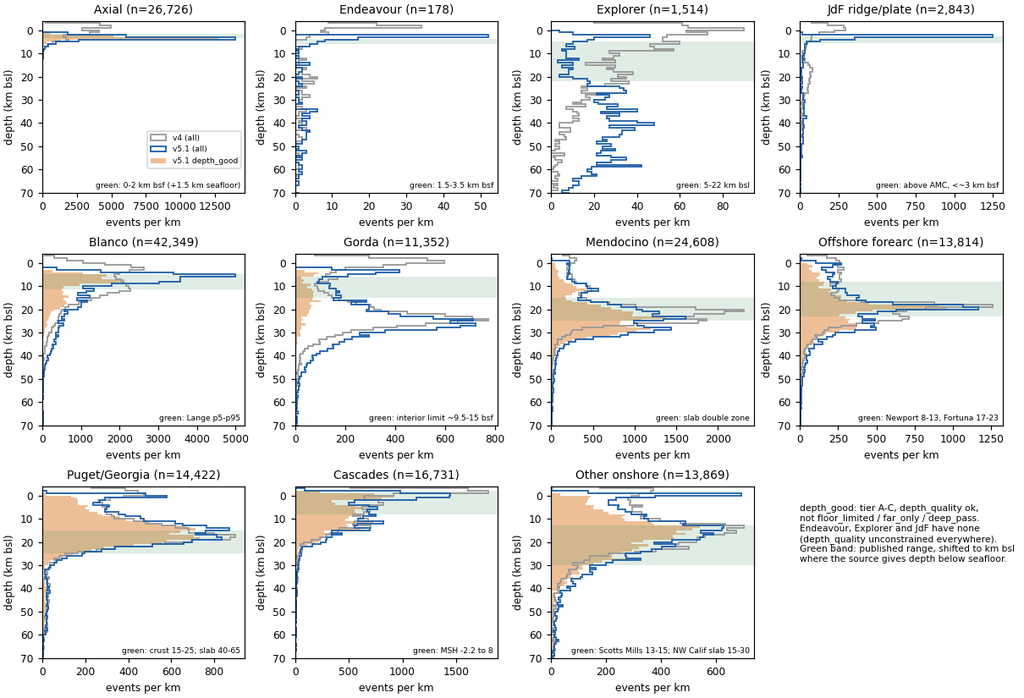

Depth distributions by region: v4 (grey), v5.1 (blue), v5.1 depth_good (orange), and the published range (green).

**Structure sharpness on the same events (nearest-neighbour distances)**

| region | depth_good | 5th-NN 3D v4 km | 5th-NN 3D v5.1 km | depth IQR v4 | depth IQR v5.1 | % sharing an epicentre | NN between distinct epicentres km | NN epicentral v4 km | NN epicentral v5.1 km |
| --- | --- | --- | --- | --- | --- | --- | --- | --- | --- |
| Axial | 20487 | 0.28 | 0.11 | 3.7 | 0.6 | 86.2 | 0.057 | 0.032 | 0.000 |
| Endeavour | 0 |  |  |  |  | 1.1 | 1.875 | 1.162 | 1.864 |
| Explorer | 0 |  |  |  |  | 0.7 | 1.106 | 0.983 | 1.085 |
| JdF ridge/plate | 0 |  |  |  |  | 5.0 | 0.568 | 0.478 | 0.511 |
| Blanco | 17116 | 1.02 | 0.93 | 7.2 | 9.0 | 19.3 | 0.127 | 0.105 | 0.114 |
| Gorda | 1506 | 2.54 | 2.60 | 16.0 | 11.0 | 2.9 | 0.388 | 0.382 | 0.366 |
| Mendocino | 17690 | 1.16 | 1.26 | 6.0 | 9.1 | 7.1 | 0.175 | 0.170 | 0.170 |
| Offshore forearc | 9402 | 2.05 | 2.10 | 9.1 | 10.1 | 8.3 | 0.346 | 0.315 | 0.322 |
| Puget/Georgia | 10736 | 2.27 | 2.08 | 9.7 | 8.5 | 3.4 | 0.382 | 0.396 | 0.366 |
| Cascades | 11650 | 0.88 | 0.79 | 11.2 | 10.9 | 23.2 | 0.170 | 0.124 | 0.114 |
| Other onshore | 9617 | 2.74 | 2.76 | 10.8 | 11.8 | 2.0 | 0.556 | 0.513 | 0.544 |

### Depths against ANSS and named benchmarks

| region | matched in both | networks | v4 - ANSS km | v5.1 - ANSS km | \|v4 - ANSS\| km | \|v5.1 - ANSS\| km | matched, all round depths dropped | v5.1 - ANSS km (round depths dropped) |
| --- | --- | --- | --- | --- | --- | --- | --- | --- |
| Gorda | 207 | nc,us,uw | 4.0 | 9.4 | 5.5 | 9.9 | 206 | 9.4 |
| Mendocino | 1740 | nc | 1.5 | 3.6 | 2.7 | 3.8 | 1740 | 3.6 |
| Offshore forearc | 895 | uw,nc,us | 1.1 | 2.3 | 4.9 | 4.6 | 893 | 2.3 |
| Puget/Georgia | 4261 | uw,us | -1.3 | -0.3 | 2.7 | 2.6 | 4260 | -0.3 |
| Cascades | 5323 | uw,nc,us | -1.1 | 1.0 | 2.2 | 1.8 | 5321 | 1.0 |
| Other onshore | 2946 | uw,nc,us | -1.6 | 0.5 | 2.9 | 2.4 | 2946 | 0.5 |

ANSS/ComCat earthquakes matched within 3 s and 20 km, fixed depths (no depth error, or us/at/pt at 0, 5, 10, 33, 35 km) removed; the last two columns drop every round ANSS depth (0, 5, 6, 10, 33, 35 km) at any network. In Gorda the verifier's mutual-nearest 2 s / 15 km match gives +7.2 km on 155 events, so the Gorda offset is quoted as +7 to +9 km. ANSS depths are network 1-D depths; the depth-literature report shows NCSN is shallower than the OBS-based studies on the Mendocino coast and PNSN is too deep off Oregon, so ANSS is a reference, not the truth.

| benchmark | n | v5.1 median | v5.1 p10 | v5.1 p90 | v4 median | literature | datum |
| --- | --- | --- | --- | --- | --- | --- | --- |
| Axial caldera, tier A-B: share within 2.0 km below seafloor | 12975 | 81.0 |  |  |  | 90 % (Waldhauser et al. 2020); 85 % within 1.6 km | % of events |
| Axial caldera, tier A-B, depth below seafloor | 12975 | 1.7 | 0.8 | 2.2 | -2.1 | 0-2 km; ring faults to the reservoir roof at ~1.1-2.3 km | bsf |
| Endeavour axial box (47.85-48.10N, 129.2-129.0W), all tiers | 36 | 2.6 | 0.7 | 57.1 | -3.8 | 1.5-3.5 km (Wilcock 2002; Van Ark 2007) | bsf |
| Explorer seaward of the front (seafloor deeper than 1.5 km) | 1214 | 44.0 | 11.3 | 64.4 | 9.3 | 5-22 km (Hutchinson et al. 2019, 2023) | bsl |
| Explorer seaward, nearest station < 30 km | 57 | 31.7 | 23.9 | 56.0 | 11.5 | 5-22 km | bsl |
| JdF ridge/plate, all tiers | 2843 | 0.8 | 0.0 | 40.2 | 2.7 | above the AMC at 2.0-2.7 km; crust 6.7-8 km (indirect) | bsf |
| Blanco, tier A-B, X9 years (2012-09 to 2013-10) | 3258 | 8.2 | 4.8 | 16.0 | 2.6 | West 0-8, east 3-13 km bsf; Lange p5-p95 4.7-11.3 km | bsf |
| Gorda interior (127-125W, 40.5-42.5N), nearest station < 10 km | 542 | 8.3 | 1.5 | 23.6 | -2.0 | faulting limit ~9.5-15 km bsf (thermal) | bsf |
| Gorda interior, all | 6187 | 22.3 | 5.7 | 33.6 | 20.3 | ~9.5-15 km bsf | bsf |
| Gorda Ridge axis (within 10 km of the PB2002 ridge), tier A-B | 51 | 21.2 | 7.7 | 30.2 | 0.5 | ~3-7 km bsf (Jones & Johnson 1978) | bsf |
| Gorda Ridge axis, tier A-B, nearest station < 15 km | 33 | 12.2 | 7.0 | 26.1 | -2.0 | ~3-7 km bsf | bsf |
| Fortuna cluster (6 km of 40.6N 124.1W), tier A-C | 1688 | 19.0 | 16.7 | 20.4 | 18.2 | 17-23 km (Alongi et al. 2021) | not stated |
| Central Puget Lowland crust, tier A-B, depth < 35 km | 1294 | 19.5 | 12.8 | 25.2 | 18.0 | 15-25 km, mean 17.6 km (Blakely 2002) | not stated (surface ~0) |
| Mount St. Helens (10 km of summit), tier A-B | 3273 | 1.5 | -0.6 | 7.5 | -0.5 | -2.2 to 2 km bsl, deeper events 2-8 km from 2016 (Hirao 2025); paired +0.76 km (paired_v5.1.md) | bsl |
| Mount St. Helens (10 km of summit), deeper than 30 km, all tiers | 290 | 68.1 | 35.9 | 104.2 | 28.6 | none expected; SHZ base ~16-20 km | bsl |

### Magnitudes

On the 130,003 events with ML in both versions, the v5.1 ML is a median 0.047 higher than v4.1 (by region: Axial -0.11, JdF ridge/plate +0.15, Endeavour +0.14, Explorer +0.10, Gorda +0.10, Mendocino +0.09, Blanco +0.06, offshore forearc +0.07, Puget/Georgia +0.00, Cascades +0.01). Large changes (|dML| > 0.5, 639 events) are 83% tier D (529; tier D is 19% of all shared events). 208 of them lie in the Mount St. Helens box, 115 of these in the waveform review's deep set (P1, likely false events); 239 are onshore outside the box (235 tier D, moved a median 56 km horizontally and 30 km deeper, ML +0.66). The first build of this report called them "not Mount St. Helens events"; that is corrected.

The magnitude piece found that the phase19 station-term inversion stops at its iteration limit without converging, in v4.1 as in v5.1. Run to convergence, whole offshore regions move in final ML (medians: Blanco -0.68, JdF ridge/plate -0.51, Gorda -0.28, Mendocino -0.28, offshore forearc -0.28, Explorer -0.08, Axial -0.04, onshore +0.01). The gap to ComCat ML shrinks (anchors with at least 3 near picks: Blanco +0.59 to +0.10, Gorda +0.33 to +0.02, Mendocino +0.54 to +0.26; anchor std 0.230 to 0.176) and offshore ML - tensor Mw (Mw 3-4.5) goes from +0.26 to -0.01. With both versions converged, the v5.1 - v4.1 change in the offshore labels outside Axial is -0.001 to +0.042 instead of +0.08 to +0.20 as stored: most of the offshore rise comes from the solver, not from the relocation; the Axial drop (-0.15 converged) is a relocation effect. Production M was not changed (PI decision pending), so every Mc, b, M1-M2 and offshore magnitude in this report uses the stored, unconverged ML.

On the same events at a common Mc, b changes by EN -0.079, BL -0.021, GO -0.032, MT -0.035, OR -0.073, PU -0.013, ON -0.060, offshore -0.029 and overall -0.029 (all beyond a Bonferroni |z| of 2.84), WA +0.000, and at Axial +0.021 at Mc 0.2 against -0.030 at Mc 0.4. These use the stored ML; a regional shift moves Mc but not b, but the b values may change once the solver converges. None of this changes a regional interpretation below, but swarm and multiplet types that hinge on M1-M2 differences of 0.3-0.5 are within the ML uncertainty, and offshore Mc and the events above it would move with a converged solver.

**ML change by region (magnitude piece)**

| region | events in both | median dML v5.1 - v4.1 | p25 | p75 | dML, phase19 events, as stored | dML, phase19 events, both converged | converged - stored ML, v5.1 |
| --- | --- | --- | --- | --- | --- | --- | --- |
| Axial | 13786 | -0.112 | -0.149 | -0.063 | -0.105 | -0.148 | -0.036 |
| Endeavour | 103 | +0.135 | +0.023 | +0.292 | +0.200 | +0.042 | +0.104 |
| Explorer | 1317 | +0.105 | +0.066 | +0.167 | +0.142 | +0.023 | -0.077 |
| JdF ridge/plate | 1499 | +0.146 | +0.028 | +0.216 | +0.193 | +0.014 | -0.507 |
| Blanco | 31245 | +0.062 | +0.033 | +0.117 | +0.095 | +0.018 | -0.683 |
| Gorda | 8093 | +0.096 | +0.082 | +0.125 | +0.119 | +0.006 | -0.281 |
| Mendocino | 18068 | +0.092 | +0.072 | +0.109 | +0.114 | +0.001 | -0.280 |
| Offshore forearc | 11704 | +0.066 | +0.028 | +0.090 | +0.083 | -0.001 | -0.277 |
| Puget/Georgia | 13972 | +0.003 | -0.012 | +0.017 | +0.001 | +0.004 | +0.015 |
| Cascades | 16461 | +0.011 | -0.010 | +0.052 | +0.010 | +0.014 | +0.015 |
| Other onshore | 13755 | +0.015 | -0.004 | +0.085 | +0.014 | +0.006 | +0.010 |

**Paired b, v5.1 against v4.1 on the same events (magnitude piece)**

| box | common Mc | n >= Mc v4.1 | n >= Mc v5.1 | b v4.1 | b v5.1 | b change | z |
| --- | --- | --- | --- | --- | --- | --- | --- |
| AX | 0.2 | 11601 | 10351 | 0.694 | 0.715 | +0.021 | +7.9 |
| AX | 0.4 | 9369 | 7813 | 0.789 | 0.759 | -0.030 | -7.5 |
| EN | 1.9 | 1214 | 1418 | 0.872 | 0.794 | -0.079 | -6.8 |
| EN | 1.8 | 1375 | 1545 | 0.814 | 0.726 | -0.087 | -9.2 |
| BL | 2.3 | 10425 | 12174 | 1.225 | 1.204 | -0.021 | -4.3 |
| BL | 2.2 | 13221 | 15227 | 1.177 | 1.148 | -0.029 | -7.4 |
| GO | 2.2 | 2618 | 3319 | 1.133 | 1.101 | -0.032 | -3.1 |
| GO | 2.1 | 3264 | 4011 | 1.093 | 1.040 | -0.053 | -5.9 |
| MT | 1.7 | 11696 | 13809 | 1.007 | 0.973 | -0.035 | -8.5 |
| WA | 1.2 | 1261 | 1341 | 0.998 | 0.998 | +0.000 | +0.0 |
| OR | 1.6 | 669 | 730 | 0.967 | 0.894 | -0.073 | -4.4 |
| PU | 1.2 | 5042 | 5029 | 1.236 | 1.222 | -0.013 | -2.9 |
| ON | 1.2 | 9676 | 9960 | 0.801 | 0.742 | -0.060 | -23.7 |
| ON | 1.3 | 8480 | 8726 | 0.849 | 0.774 | -0.075 | -24.0 |
| OFF | 2.2 | 16794 | 19779 | 1.152 | 1.123 | -0.029 | -8.1 |
| ALL | 2.1 | 27735 | 32421 | 1.054 | 1.025 | -0.029 | -11.2 |
| ON without MSH | 1.2 | 8779 | 9042 | 0.802 | 0.754 | -0.049 | -21.5 |
| MSH only | -0.1 | 8139 | 8359 | 0.687 | 0.670 | -0.017 | -6.9 |

### Fault surfaces

| region | v1 surfaces | steep | fit members | stable (reruns) | recovered 80% | recovered A-B | v0 surfaces | v0 members | located eq | % on a surface (strict) | % member or assigned | ambiguous | no surface | not fitted (Axial) | weekday-daytime members of removed surfaces | RMS v0 km | RMS v1 km |
| --- | --- | --- | --- | --- | --- | --- | --- | --- | --- | --- | --- | --- | --- | --- | --- | --- | --- |
| Axial | 0 | 0 | 0 | 0 | 0 | 0 |  |  | 26726 |  |  | 0 | 58 | 26668 | 0 |  |  |
| Endeavour | 0 | 0 | 0 | 0 | 0 | 0 |  |  | 178 | 0.0 | 0.0 | 0 | 178 | 0 | 0 |  |  |
| Explorer | 5 | 5 | 305 | 4 | 2 | 0 | 3.0 | 158.0 | 1514 | 21.1 | 38.5 | 18 | 913 | 0 | 0 | 1.0 | 1.0 |
| JdF ridge/plate | 2 | 2 | 122 | 1 | 1 | 0 | 1.0 | 121.0 | 2843 | 4.1 | 16.5 | 1 | 2202 | 206 | 0 | 0.7 | 0.7 |
| Blanco | 18 | 18 | 24323 | 7 | 0 | 0 | 20.0 | 18352.0 | 42349 | 59.0 | 64.0 | 11749 | 3490 | 0 | 0 | 0.7 | 0.7 |
| Gorda | 28 | 21 | 5256 | 6 | 6 | 2 | 21.0 | 2988.0 | 11352 | 48.4 | 58.1 | 2381 | 2374 | 0 | 0 | 1.1 | 1.2 |
| Mendocino | 17 | 7 | 14910 | 2 | 4 | 0 | 17.0 | 11710.0 | 24608 | 57.5 | 65.1 | 5305 | 3290 | 0 | 0 | 1.2 | 1.3 |
| Offshore forearc | 18 | 12 | 5348 | 8 | 9 | 2 | 14.0 | 5332.0 | 13814 | 41.1 | 49.8 | 2313 | 4589 | 0 | 37 | 1.2 | 1.1 |
| Puget/Georgia | 19 | 7 | 3623 | 3 | 4 | 2 | 28.0 | 5293.0 | 14422 | 24.5 | 36.8 | 548 | 7946 | 0 | 623 | 1.3 | 1.4 |
| Cascades | 14 | 12 | 7802 | 9 | 6 | 1 | 16.0 | 6337.0 | 16731 | 45.8 | 52.8 | 3249 | 4619 | 0 | 24 | 1.0 | 1.2 |
| Other onshore | 21 | 15 | 2583 | 9 | 6 | 3 | 21.0 | 3000.0 | 13869 | 27.1 | 37.3 | 693 | 7809 | 0 | 200 | 1.1 | 1.2 |

v1 has 142 surfaces against 141 in v0, but the share of the fit set on a surface fell from 70% to 63% because the dip rule is now applied after every reassignment. Uncertainty is reported at two levels. For a fixed set of members, the median sigma_total is 0.59 km and strike/dip intervals are a few degrees. Across detection reruns, 93 of 142 surfaces are unstable and their strike range has a median of 103° (6.5° for the 49 stable ones). Of the 130 non-strand surfaces, 38 are recovered (Jaccard >= 0.5) on a random 80% subsample, 12 after moving every event once by its own error and 10 of 116 on tiers A-B only; 9 pass both the subsample and the perturbation test (the verifier's detection reruns, now carried in the faults product). The 12 Blanco strands have no recovery test. In this report a surface is called robust only if it is stable and recovered on the subsample (J >= 0.5): 27 surfaces. Detection robustness says nothing about depth: v1_GO022 (Brookings, review P2) and v1_ON017 (members moved +15 km) are among them.

Counting events on faults: the faults piece now marks 65,709 events on_surface_strict (fit members, plus tier A-C events assigned to one surface within 2 km, without floor_limited, far_only or deep_pass). The looser "assigned" class (compatible with one surface; 45% tier D, 4,899 more than 5 km from it) is kept in the table as "% member or assigned"; both leave Axial out. 884 events are weekday-daytime members of surfaces removed for their timing (likely blasts). Literature matches are carried unchanged to 15 surfaces, 88 carry a match marked for re-check and 39 are new.

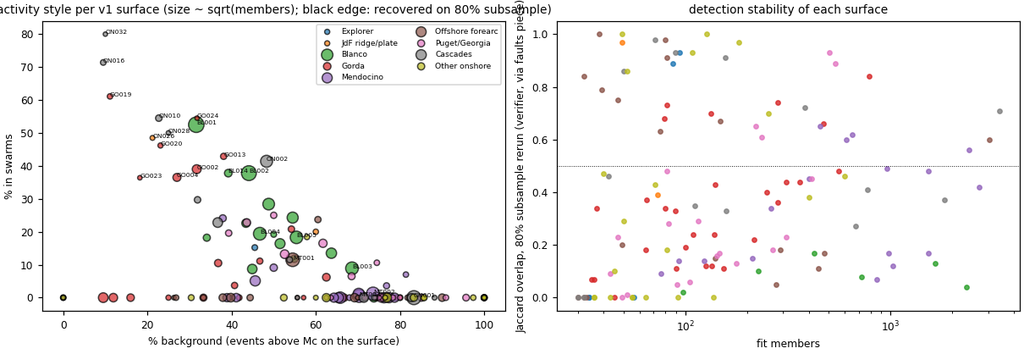

Left: share of events above Mc that are background or in swarms, per v1 surface. Right: Jaccard overlap of each surface with the verifier 80% subsample rerun.

### Clustering

| region | n >= Mc | % bg | % MA | % swarm | % multiplet | n >= Mc v4 | % bg v4 | % MA v4 | % swarm v4 | % tier D | % bg of tier D | % bg of A-C | MA families (>=5) | swarms (>=5) |
| --- | --- | --- | --- | --- | --- | --- | --- | --- | --- | --- | --- | --- | --- | --- |
| Axial | 4322 | 61.1 | 11.1 | 20.6 | 7.2 | 4282 | 50.4 | 15.2 | 25.5 | 32.5 | 80.1 | 51.9 | 14 | 40 |
| Endeavour | 35 | 68.6 | 14.3 | 17.1 | 0.0 | 29 | 62.1 | 20.7 | 17.2 | 65.7 | 78.3 | 50.0 | 0 | 1 |
| Explorer | 470 | 53.8 | 40.4 | 2.1 | 3.6 | 442 | 54.3 | 41.2 | 1.1 | 24.3 | 73.7 | 47.5 | 3 | 2 |
| JdF ridge/plate | 931 | 56.7 | 12.0 | 18.0 | 13.2 | 736 | 57.7 | 13.2 | 15.1 | 59.6 | 70.6 | 36.2 | 4 | 18 |
| Blanco | 7227 | 52.4 | 12.4 | 25.5 | 9.6 | 6115 | 50.2 | 17.6 | 22.3 | 7.8 | 73.1 | 50.7 | 35 | 69 |
| Gorda | 2637 | 41.1 | 49.0 | 5.3 | 4.7 | 2682 | 41.5 | 49.3 | 5.6 | 11.1 | 73.0 | 37.0 | 14 | 11 |
| Mendocino | 3912 | 68.9 | 25.4 | 1.1 | 4.6 | 4016 | 69.6 | 24.4 | 1.4 | 16.6 | 64.8 | 69.7 | 23 | 7 |
| Offshore forearc | 2559 | 58.1 | 34.2 | 2.8 | 4.8 | 2425 | 52.0 | 39.4 | 3.1 | 23.2 | 48.7 | 61.0 | 11 | 9 |
| Puget/Georgia | 3459 | 79.2 | 11.9 | 3.6 | 5.3 | 2854 | 79.6 | 11.6 | 3.6 | 15.8 | 97.4 | 75.7 | 14 | 12 |
| Cascades | 1901 | 65.6 | 9.3 | 13.6 | 11.5 | 1530 | 64.1 | 10.7 | 14.0 | 27.9 | 73.3 | 62.6 | 8 | 22 |
| Other onshore | 2748 | 84.4 | 8.7 | 2.3 | 4.6 | 2443 | 84.4 | 9.7 | 1.4 | 33.1 | 88.2 | 82.5 | 6 | 9 |

| box | % bg v4 | % bg v5.1 | % bg tier A-C only | % bg conservative eta0 | % bg Mc_best | % bg noM_floor | % bg min (variants) | % bg max (variants) | real linked fraction | shuffled linked fraction | shuffled / real | shuffled within month / real | swarms real | swarms shuffled | h_max tier D km | h_max tier A-C km | % links with a tier D end |
| --- | --- | --- | --- | --- | --- | --- | --- | --- | --- | --- | --- | --- | --- | --- | --- | --- | --- |
| AX | 50.6 | 61.8 | 42.9 | 81.8 | 74.7 | 38.1 | 38.1 | 81.8 | 0.30 | 0.23 | 0.75 | 0.79 | 40 | 14.5 | 4.8 | 1.8 | 18.8 |
| BL | 50.2 | 52.5 | 50.8 | 63.6 | 52.2 | 60.2 | 50.8 | 63.6 | 0.40 | 0.15 | 0.39 | 0.62 | 70 | 12.8 | 28.0 | 1.9 | 6.1 |
| EN | 51.6 | 49.8 | 46.0 | 66.8 | 46.1 | 52.2 | 46.0 | 66.8 | 0.44 | 0.12 | 0.26 | 0.80 | 5 | 0.4 | 36.0 | 4.1 | 13.4 |
| GO | 60.8 | 60.3 | 56.7 | 67.2 | 59.9 | 66.8 | 56.7 | 67.2 | 0.31 | 0.09 | 0.28 | 0.63 | 12 | 0.1 | 22.6 | 2.5 | 8.0 |
| MT | 57.5 | 57.5 | 58.8 | 74.3 | 61.5 | 66.6 | 56.0 | 74.3 | 0.37 | 0.15 | 0.42 | 0.81 | 13 | 9.7 | 9.1 | 1.7 | 17.7 |
| ON | 69.4 | 69.6 | 66.4 | 71.8 | 71.2 | 65.7 | 65.3 | 72.7 | 0.23 | 0.05 | 0.21 | 0.75 | 43 | 1.3 | 31.9 | 3.6 | 47.9 |
| OR | 68.4 | 75.6 | 63.2 | 83.7 | 76.2 | 72.9 | 61.8 | 83.7 | 0.18 | 0.09 | 0.48 | 0.92 | 0 | 0.1 | 34.4 | 2.8 | 23.3 |
| PU | 79.0 | 78.8 | 74.9 | 81.9 | 78.0 | 79.4 | 74.9 | 82.3 | 0.15 | 0.04 | 0.29 | 0.78 | 14 | 0.3 | 37.7 | 1.2 | 2.7 |
| WA | 84.2 | 84.4 | 81.4 | 87.0 | 83.0 | 87.5 | 80.5 | 87.5 | 0.10 | 0.03 | 0.30 | 0.83 | 3 | 0.2 | 45.1 | 1.7 | 5.9 |

The mixture of log eta is not a test of clustering. Its separation (Ashman D) is below 2 in WA, OR and PU, and a density valley between the two modes exists only in EN, BL, GO and MT. With the v4 single-start mixture fit no shuffled catalog reaches the real D (largest shuffled D: AX 2.19 against 2.23 real, EN 3.12 against 3.31, MT 2.21 against 2.41), but shuffled D depends on the fit; the verifier's multi-start fits reach 5.35 at AX and 3.0 at OR. The useful measure is the share of the real links that a time-shuffled catalog reproduces (clustering piece's null test, 10 shuffles over 2010-2016; table above): ON 0.21, EN 0.26, GO 0.28, PU 0.29, WA 0.30, BL 0.39, MT 0.42, OR 0.48, AX 0.75. Shuffling within the calendar year gives 0.33-0.77 and within the month 0.62-0.92, so much of the clustering at every box is rate variation on monthly scales. Shuffled catalogs reproduce fewer swarms (AX 14.5 against 40, BL 12.8 against 70, MT 9.7 against 13). Tier D epicentres are poor outside Axial (median h_max 9-45 km by box, 4.8 km at Axial, against 1.2-4.1 km for tiers A-C); 16% of the links have a tier D end, 48% in the ON box. Whether tier D stays in the main run is a pending PI decision (the clustering piece proposes a tier A-C main run with tier D attached; variant tierABC exists).

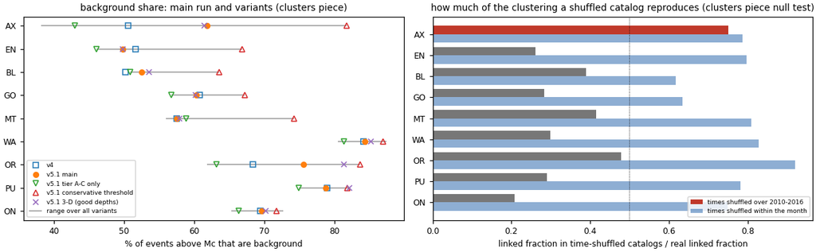

Left: background share in the main run and variants. Right: linked fraction in time-shuffled catalogs relative to the real catalog (clustering piece null test; grey/red: shuffled over 2010-2016, blue: within the month); grey bars on the left: range over all variants.

## Axial

#### What the v5.1 locations change

26,731 rows, 26,726 located (5 without a hypocentre, left out), 0 flagged non-earthquakes. Tiers A/B/C/D: 15/34/31/20%. floor_limited 1,562, far_only 0, deep_pass 3; depth_good (tier A-C, depth_quality ok, no flag) 20,487. Median depth of located earthquakes: v4 0.3 km, v5.1 3.3 km bsl (1.8 km below the surface); median shift 3.2 km horizontally, +3.0 km in depth. Median sig_z 1.8 km, nearest station 1 km. In v4, 70% of these events plot above the ground or seafloor if v4 depth is read as km bsl.

v5.1 places the caldera seismicity in a band 1-3 km below the seafloor: tier A-B median 1.67 km below the seafloor, p10-p90 0.79-2.16 km, and 81% of the 12,975 tier A-B events within 2.0 km of the seafloor (Waldhauser et al. 2020: 90%; acceptance target 85%; v4-NLL3D 79%, B4 at model v0.3.0 12%). The v4 depths cannot be compared directly: read as km bsl, 70% of them are above the seafloor. The v4 picture of "two lobes between -2 and 2 km with a second cluster at 4-5 km" does not survive: the 2,029 tier A-B events that v4 put at 3.5-5.5 km are at a median 1.8 km below the seafloor in v5.1, the same as the rest. The v4 western lobe (1,843 tier A-B events at a median 130.059°W) moved 3.3 km east to 130.017°W, onto the western caldera wall. The east-to-west event ratio across 130.00°W is 4.3 (v4 4.2; about 5 in Wilcock et al. 2016).

The v5.1 Axial locations are quantised: 86% of located events share their exact epicentre with at least one other event (96% of tiers A-B; stacks of up to 38 events on a lattice of about 60 m, the final oct-tree cell), and 43% of the region's events sit on a broad plateau of oct-tree depth levels between 2.9 and 3.6 km bsl (figure "depth spikes" in the catalog problems section). Nearest-neighbour distances and ring-fault widths below about 100 m are therefore not measured by v5.1. The first build of this report counted 3,462 events "in excess" at the 3 km depth node of model v0.3.1 and concluded that part of the 81% within 2 km of the seafloor was set by the model grid. That is withdrawn. Its metric (events within 0.25 km against the 0.25-1.25 km flanks) measures how peaked the depth mode is, and it gives a slightly larger value at 3.5 km bsl, which is not a node (7,132 against 3,514 expected, ratio 2.03; 3.0 km: 1.94). A local spike test (events within 0.1 km against the bins 0.3 km either side) gives 1.07 at 3.0 km and 1.06 at 3.5 km: no pile-up at the node. 1,562 events are floor_limited (450 of them tier A-B; without them 80.3% of tiers A-B are within 2 km of the seafloor).

#### Faults: which are active and how

Axial was left out of the fault fit (as in v0), so its events are neither on nor off a surface. The faults piece labels the 26,874 located events of its AX box "not fitted (Axial Seamount left out)"; that box also holds 206 events of the JdF ridge/plate region. Of the 26,726 located earthquakes of the Axial region, 26,668 are not fitted and 58 lie in a neighbouring, fitted box with no compatible surface ("none"). The published ring-fault geometry (outward-dipping faults from the surface to the reservoir roof at about 1.1-2.3 km, Wilcock et al. 2016; less than 200 m wide, Waldhauser et al. 2020) is finer than the v5.1 cell lattice, so a v5.1 surface fit would not add to it.

**v1 surfaces with most members in this region**

No v1 surface in this region.

#### Sequences, swarms and background

4,322 earthquakes above Mc: 61% background, 11% in mainshock-aftershock families, 21% in swarms, 7% in multiplets (v4: 50% / 15% / 25% for background / MA / swarm). Families of 5 or more above Mc led by an event here: mainshock-aftershock 14, swarms 40. Tier D events are 33% of the analysis set here, and 80% of them are background (tiers A-C: 52%).

The rate history is the same as in v4 because the events are the same: 670 located events in November 2014, 8,158 in March 2015, 7,271 in April 2015, then 570 in May and about 50-140 a month to the end of 2016. The eruption onset (family 1872, from 2015-04-24 05:13 UTC) is one 513-event swarm with 495 events above Mc (v4: 805 and 632) that lasted 0.6 day at the 90% level.

The Axial background/clustered split is not a robust result. The background share is 61.8% in the main run, 42.9% without tier D, 81.8% with the conservative threshold, 74.7% at the lower Mc of the magnitude piece and 38.1% when the 13,008 Axial events without M are given M = Mc (variant noM_floor): over all variants 38-82%. Time-shuffled catalogs reproduce 75% of the real links (clustering piece's null test, mean of 10 shuffles; 79% when times are shuffled within the month), because the 4,410 events above Mc sit in a 5 km caldera and most occur in the months of rising rate before the eruption, which shuffling keeps. The v4 statement that Axial has the lowest background share and the most swarms per event therefore rests mostly on links that a shuffled catalog also makes. The swarm count holds up better: shuffled catalogs form 14.5 swarms on average against 40 in the real catalog. The tier D events here are a special case: median h_max 4.8 km (tiers A-C 1.8 km), seen from outside the caldera network (median azimuthal gap 327°), and 80% of them are background.

#### Swarm and sequence characteristics

All 40 Axial swarms of 5 or more events above Mc are on the caldera (all within 25 km of the summit by construction; nearest PB2002 step is the JdF-PA transform offset). Their median duration at the 90% level is 17 minutes and median extent 1.6 km, below the 2 km scale at which v5.1 can resolve spreading (none is resolvable). In the eruption swarm (figure below) the first 34 events (first 1.2 hours) are centred 2.3 km north and 0.6 km east of the caldera centre (45.95°N, 130.00°W) at a median 2.9 km below the seafloor; from 0.05 day on, the activity is centred 0.8 km east of the centre, spans about 3 by 3 km (p10-p90) and stays at a median 1.8-2.0 km below the seafloor, about the depth of the reservoir roof. The rift-zone seismicity of the eruption lies largely outside the Axial region box and is not analysed here.

**Largest families led by an event in this region**

| family | type | start (UTC) | events (>=Mc) | Mmax | t90 days | extent km | good-depth median km | n good | resolvable spread | migrating | on surfaces | main surface | nearest boundary | v4 status |
| --- | --- | --- | --- | --- | --- | --- | --- | --- | --- | --- | --- | --- | --- | --- |
| 1872 | swarm | 2015-04-24 05:13 | 513 (495) | 4.3 | 0.6 | 6.9 | 3.4 | 455 | False | False |  |  | OTF 5 km | kept |
| 1744 | swarm | 2015-03-23 22:08 | 59 (26) | 3.0 | 0.1 | 2.3 | 4.4 | 36 | False | False |  |  | OTF 6 km | kept |
| 1792 | swarm | 2015-04-01 13:49 | 57 (14) | 2.4 | 0.0 | 0.9 | 3.2 | 56 | False | False |  |  | OTF 3 km | kept |
| 1564 | swarm | 2015-01-31 00:34 | 54 (13) | 3.5 | 0.0 | 1.5 | 3.3 | 54 | False | False |  |  | OTF 3 km | kept |
| 1882 | swarm | 2015-04-24 22:19 | 44 (28) | 3.3 | 0.1 | 4.9 | 3.3 | 42 | False | False |  |  | OTF 3 km | merged |
| 1576 | swarm | 2015-02-02 23:41 | 44 (18) | 3.0 | 0.1 | 3.9 | 3.2 | 43 | False | False |  |  | OTF 2 km | kept |

#### Against published studies

Agrees: rate history and timing of the pre-eruption acceleration and the drop after 24 April 2015 (Wilcock et al. 2016); the east-wall dominance (ratio 4.3 against about 5). Partly agrees: depth, 81% within 2.0 km against 90% (Waldhauser et al. 2020); p90 of tiers A-B is 2.16 km below the seafloor, so the deep tail is short, and the agreement does not rest on a pile-up at the 3 km model node (none is found with a local spike test). Not testable: ring-fault width and dip.

#### v4-era interpretations that no longer hold

- v4 'second cluster at 4-5 km' (science report): not in v5.1; those events are at the same depth as the rest.
- v4 'lowest background share and most swarms per event' (v4 clusters): the split moves from 38% to 82% background with the variant, and shuffled catalogs reproduce 75% of the links; it is not a setting result.
- v4 western lobe at 130.06°W: moved 3 km east onto the caldera wall.

**Uncertainty.** Locations are quantised on a ~60 m oct-tree lattice; tier D events (33% of the analysis set) are poorly located from outside the caldera network.

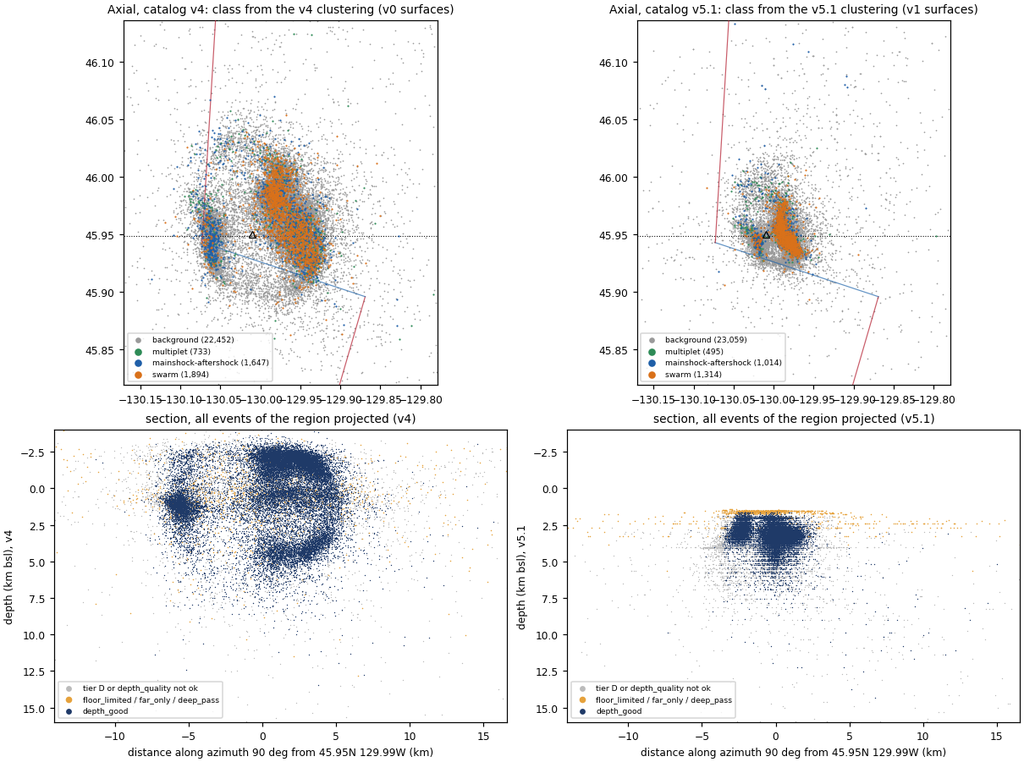

Axial: v4 (left) and v5.1 (right) maps coloured by cluster class, and sections of all events along 90°.

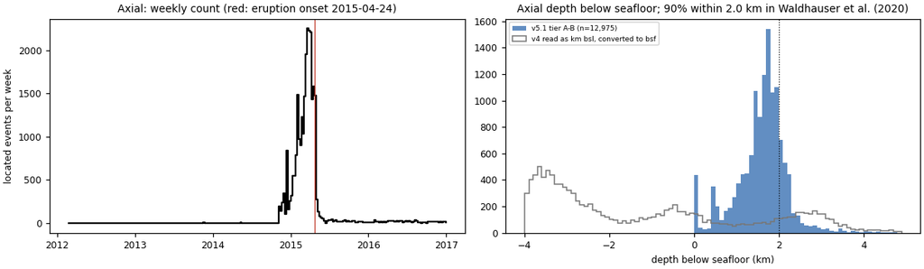

Axial: weekly event count and depth below seafloor of tier A-B events.

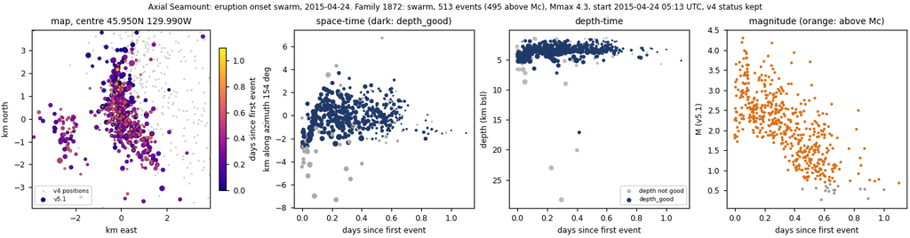

Axial eruption-onset swarm (family 1872): map coloured by time, along-axis distance, depth and magnitude against time.

## Endeavour

#### What the v5.1 locations change

179 rows, 178 located (1 without a hypocentre, left out), 0 flagged non-earthquakes. Tiers A/B/C/D: 0/2/24/74%. floor_limited 47, far_only 0, deep_pass 1; depth_good (tier A-C, depth_quality ok, no flag) 0. Median depth of located earthquakes: v4 1.4 km, v5.1 10.8 km bsl (8.2 km below the surface); median shift 5.6 km horizontally, +6.9 km in depth. Median sig_z 14.0 km, nearest station 29 km. In v4, 54% of these events plot above the ground or seafloor if v4 depth is read as km bsl.

Endeavour depths are not constrained in v5.1: depth_quality is "unconstrained" for every event, the median sig_z is 14 km and the nearest station is a median 29 km away (only KEMF and NCHR are on the segment). Half of the events (89 of 178) are more than 8 km below the seafloor, under a crust 6-8 km thick, and 45 are within 0.25 km of the seafloor (47 floor_limited). The 36 events in the axial box (47.85-48.10°N) have a median of 2.6 km below the seafloor, which looks like the published 1.5-3.5 km band, but their p90 is 57 km. This is the two-boundary pattern described in the depth-literature report (pinned at the seafloor or 15-55 km deep), not a measurement.

#### Faults: which are active and how

No v1 surface has most of its members here; v0 EN001 (121 events) is lost because only 10% of its events pass the fit selection.

**v1 surfaces with most members in this region**

No v1 surface in this region.

#### Sequences, swarms and background

35 earthquakes above Mc: 69% background, 14% in mainshock-aftershock families, 17% in swarms, 0% in multiplets (v4: 62% / 21% / 17% for background / MA / swarm). Families of 5 or more above Mc led by an event here: mainshock-aftershock 0, swarms 1. Tier D events are 66% of the analysis set here, and 78% of them are background (tiers A-C: 50%). With 35 events above Mc 2.35 the region cannot support a statement on its own; the Endeavour-Explorer box (EN, 554 events) is dominated by Explorer and the 2014 Vancouver Island aftershocks.

#### Swarm and sequence characteristics

The southern Endeavour / northern Juan de Fuca swarms (47.5-47.8°N, 129.1-129.35°W; 501 located events in the Endeavour and JdF regions, 2011-2014, most in 2014) include family 1119 (2014-02-09, 35 events) in this region and families 1066 and 1003 just south of it (JdF section below). They sit 14-23 km from the PB2002 ridge and transform steps and are pinned at the seafloor (72% floor_limited, median 0.05 km below the seafloor), so only their epicentres and timing can be used.

**Largest families led by an event in this region**

| family | type | start (UTC) | events (>=Mc) | Mmax | t90 days | extent km | good-depth median km | n good | resolvable spread | migrating | on surfaces | main surface | nearest boundary | v4 status |
| --- | --- | --- | --- | --- | --- | --- | --- | --- | --- | --- | --- | --- | --- | --- |
| 1119 | swarm | 2014-02-09 19:47 | 35 (11) | 3.3 | 0.7 | 14.4 |  | 0 | False | False | 0.0 |  | OTF 14 km | kept |
| 1187 | mainshock-aftershock | 2014-03-19 08:04 | 18 (4) | 3.6 | 0.3 | 12.3 |  | 0 | False | False | 0.0 |  | OTF 24 km | kept |
| 2065 | mainshock-aftershock | 2016-05-07 00:33 | 3 (3) | 4.7 | 0.2 | 12.8 |  | 0 |  |  | 0.0 |  | OTF 15 km | changed |
| 1055 | mainshock-aftershock | 2014-01-02 11:21 | 2 (2) | 3.4 | 0.1 | 9.4 |  | 0 |  |  | 0.0 |  | OTF 15 km | kept |

#### Against published studies

Not testable for depth (Weekly et al. 2013; Krauss et al. 2023: on-axis events 1.5-3.5 km below the seafloor). The segment remains quiet in our catalog except for the southern swarms, consistent with the post-2005 extensional lull of Weekly et al. (2013) and with Krauss et al. (2025) only as an upper bound, because small on-axis events are not detected without the NV stations close by.

#### v4-era interpretations that no longer hold

- v4 'median QC depth 12.4 km, deep for a ridge' (science report): v5.1 does not resolve it either; half the events are deeper than 8 km below the seafloor and a quarter are pinned at it.
- v4 Endeavour surfaces (EN001-EN004) as fault planes: their depths and dips are not usable (0% depth_quality ok).

**Uncertainty.** Report epicentres only.

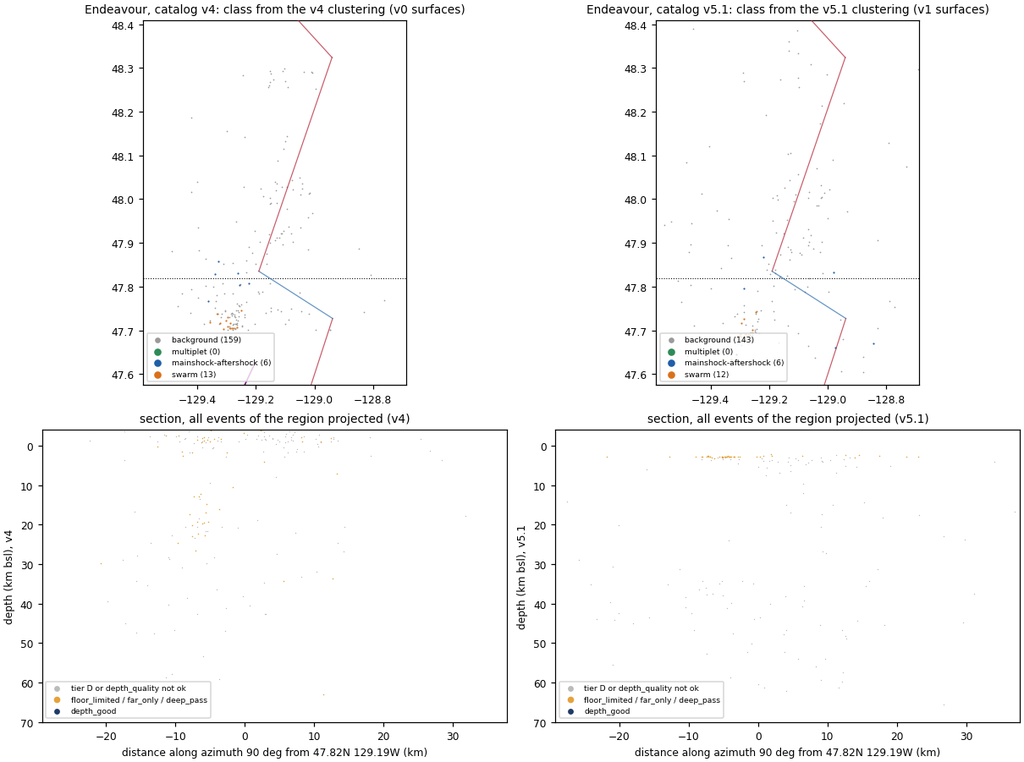

Endeavour: v4 and v5.1 maps and sections.

## Explorer

#### What the v5.1 locations change

1,523 rows, 1,514 located (9 without a hypocentre, left out), 0 flagged non-earthquakes. Tiers A/B/C/D: 0/1/64/35%. floor_limited 50, far_only 24, deep_pass 27; depth_good (tier A-C, depth_quality ok, no flag) 0. Median depth of located earthquakes: v4 9.0 km, v5.1 40.5 km bsl (38.3 km below the surface); median shift 7.8 km horizontally, +25.3 km in depth. Median sig_z 10.6 km, nearest station 75 km. In v4, 26% of these events plot above the ground or seafloor if v4 depth is read as km bsl.

The Explorer depths moved the wrong way. Seaward of the deformation front (1,214 events with the seafloor deeper than 1.5 km), the v5.1 median is 44 km bsl (p10-p90 11-64 km) against 9 km in v4 and 5-22 km bsl in the OBS studies (Hutchinson et al. 2019, 2023), with the Moho at 12-15 km bsl. The 57 seaward events with a station within 30 km are at a median 32 km. Explorer has the largest median depth shift of any region (+25 km), no depth_good event, median nearest station 75 km, 24 far_only and 27 deep_pass events. The ComCat moment-tensor events show the same bias: v5.1 is a median 24.9 km deeper than ComCat in Explorer (+13.7 km over all tensor events; magnitude piece and waveform review P3). The waveform review (P4) also finds that far_only events moved from near the surface in v4 to 44-64 km. These depths are location errors (depth traded against origin time with every station on one side), not mantle seismicity.

#### Faults: which are active and how

v1 surfaces with most of their members here: 5 (5 steep, 305 fit members; v0: 3 surfaces, 158 members). Stable under the builder's detection reruns: 4; recovered on the verifier's 80% subsample: 2; on tiers A-B only: 0. Of the 1,514 located earthquakes in fitted boxes, 39% are fit members or assigned (loose), 18 are ambiguous and 913 are on no surface; 21% are on a surface by the strict rule (on_surface_strict). Median RMS scatter of members about their surface: v0 1.02 km, v1 1.03 km. All five Explorer surfaces sit at 30-60 km on events whose depth_quality is "unconstrained"; their map traces can be used, their depths and dips cannot. v1_EN002 (87 events, strike 332°) keeps the v0 match to the fault of the 2014 Mw 6.4 Nootka sequence inside the subducted Explorer plate (Hutchinson et al. 2020); v1_EN001 keeps the eastern Sovanco fracture zone match.

**v1 surfaces with most members in this region**

| surface | events | strike | dip | depth km | depth ok | stable (reruns) | J 80% subsample | % bg | % swarm | v0 link | members dz v4->v5.1 | literature (carried from v0) | flags (faults piece, shortened) | notes added here |
| --- | --- | --- | --- | --- | --- | --- | --- | --- | --- | --- | --- | --- | --- | --- |
| v1_EN001 | 94 | 121.0 | 78.0 | 45.4 | 0.0 | True | 0.93 | 46.0 | 15.0 | matched |  | Eastern Sovanco fracture zone, conjugate-fault deformation zone | depth poorly constrained; deep centroid; moved +29.4 km v4->v5.1; not recovered 2/3 |  |
| v1_EN002 | 87 | 332.0 | 70.0 | 29.7 | 0.0 | True | 0.89 | 0.0 | 0.0 | matched |  | 2014 Mw 6.4 Nootka sequence fault inside the subducted Explorer plate | depth poorly constrained; deep centroid; moved +18.1 km v4->v5.1; not recovered 1/2 |  |
| v1_EN003 | 56 | 186.0 | 48.0 | 60.3 | 0.0 | True | 0.00 | 0.0 | 0.0 | new |  |  | depth poorly constrained; deep centroid; moved +41.9 km v4->v5.1; not recovered 2/3 |  |
| v1_EN004 | 34 | 293.0 | 86.0 | 45.7 | 0.0 | True | 0.00 | 40.0 | 0.0 | matched |  | Nootka fault zone, southern primary fault (SNF), or a N–S conjugate fault inside the zone | depth poorly constrained; deep centroid; moved +34.0 km v4->v5.1; not recovered 2/2 |  |
| v1_EN005 | 34 | 351.0 | 63.0 | 39.4 | 0.0 | False | 0.00 | 67.0 | 0.0 | new |  |  | depth poorly constrained; deep centroid; moved +33.7 km v4->v5.1; unstable; not recovered 3/3 |  |

#### Sequences, swarms and background

470 earthquakes above Mc: 54% background, 40% in mainshock-aftershock families, 2% in swarms, 4% in multiplets (v4: 54% / 41% / 1% for background / MA / swarm). Families of 5 or more above Mc led by an event here: mainshock-aftershock 3, swarms 2. Tier D events are 24% of the analysis set here, and 74% of them are background (tiers A-C: 47%).

The 2014-04-24 Mw 6.5 Vancouver Island mainshock (event 89617) is in this region. In v5.1 its family has 300 events and a t90 of 280 days because a 2013-08-04 M 5.5 event (64836) is now linked to it as a foreshock. That link comes from a tier D epicentre: event 64836 has h_max 24 km and was 33 km from the mainshock in v4; it is 1.1 km from it in v5.1 only because both moved (the mainshock by 23 km). Without tier D (variant tierABC) the family is a normal sequence of 73 events with a t90 of 16 days. The revised clustering piece reports this link as a location artefact.

#### Swarm and sequence characteristics

The 2012-02-04 M 5.6 sequence (family 296) is the family with the strongest migration statistic in the catalog (radial speed 0.8 km/day toward the north-northeast over four months, Spearman rho 0.71; permutation p = 0.0005, the smallest value 2,000 permutations give, which survives a Bonferroni correction over the 67 resolvable families, p < 0.00075). The space-time plot shows that this is a step, not a front: the 60 events of the first day are centred 6 km SSW of the family centroid, and the 47 events of 13-19 February (with an M 4.7 on 16 February) form a second cluster about 15 km to the NNE, at +9 km along 17°. A second patch activated 9-12 days after the mainshock; the envelope exponent of 0.15 says the same. Its v5.1 depths (median 55 km, v4 1.8 km) are not physical, so this is a map-view result only. Explorer has only two swarms of 5 or more events above Mc.

**Largest families led by an event in this region**

| family | type | start (UTC) | events (>=Mc) | Mmax | t90 days | extent km | good-depth median km | n good | resolvable spread | migrating | on surfaces | main surface | nearest boundary | v4 status |
| --- | --- | --- | --- | --- | --- | --- | --- | --- | --- | --- | --- | --- | --- | --- |
| 833 | mainshock-aftershock | 2013-08-04 13:22 | 300 (107) | 6.5 | 279.8 | 100.1 | 31.7 | 11 | True | False | 31.0 | v1_EN002 | SUB 31 km | kept |
| 296 | mainshock-aftershock | 2012-02-04 12:27 | 132 (45) | 5.6 | 11.9 | 24.0 |  | 0 | True | True | 41.0 | v1_EN003 | SUB 44 km | kept |
| 482 | mainshock-aftershock | 2012-11-08 02:01 | 91 (21) | 6.1 | 12.1 | 45.4 |  | 0 | True | False | 1.0 | v1_EN005 | OTF 47 km | kept |
| 899 | swarm | 2013-09-20 18:26 | 18 (5) | 3.6 | 0.5 | 6.1 |  | 0 | False | False | 72.0 | v1_EN001 | OSR 21 km | kept |
| 1038 | mainshock-aftershock | 2013-12-15 18:11 | 15 (3) | 4.6 | 22.6 | 1.4 |  | 0 | False | False | 73.0 | v1_EN004 | SUB 14 km | kept |
| 1213 | mainshock-aftershock | 2014-04-01 05:05 | 11 (3) | 4.7 | 6.9 | 12.0 |  | 0 |  |  | 36.0 | v1_EN001 | OTF 19 km | kept |

#### Against published studies

Disagrees on depth with every OBS study (5-22 km bsl seaward, Hutchinson et al. 2019, 2023; centroids 4-15 km below the seafloor, Braunmiller & Nábělek 2002). Map patterns (Sovanco, Nootka) agree with the v0 literature matches.

#### v4-era interpretations that no longer hold

- v4 Explorer depths (median 9 km) were closer to the literature than v5.1 (40 km); neither is a constraint.
- v4/v0 Explorer surfaces as dipping faults at depth: not usable; only traces.
- v4 2012-02-04 and 2012-11 Explorer sequences 'expand at 0.2-1.2 km/day': the 2012-11 sequence no longer passes the test; the 2012-02-04 one passes because a second cluster 15 km NNE started 9-12 days later (a step, not a front).

**Uncertainty.** Report epicentres only; flag the 2014 Vancouver Island family duration as an artefact of one tier D link.

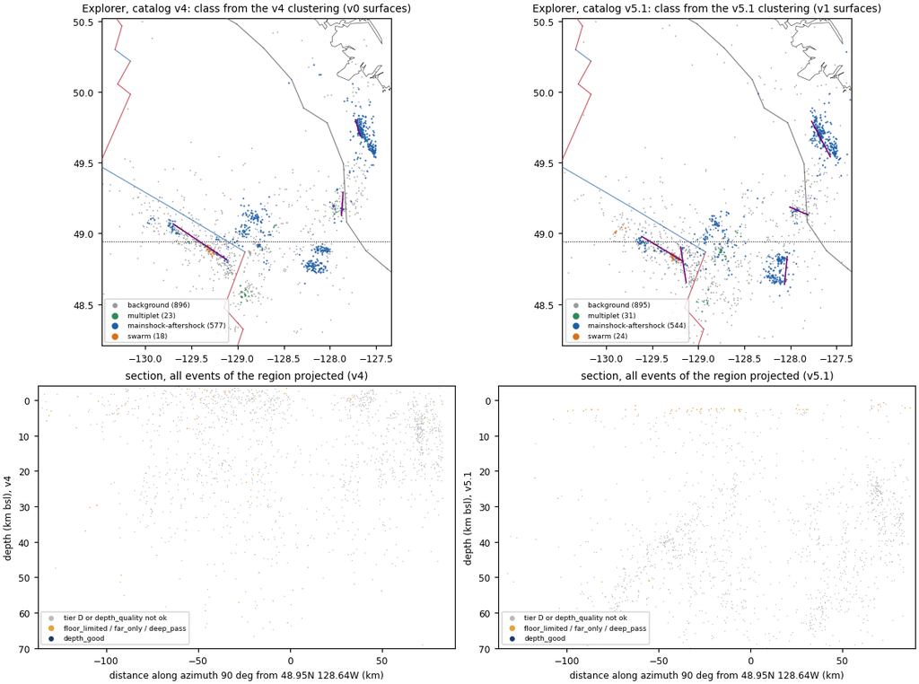

Explorer: v4 and v5.1 maps and sections.

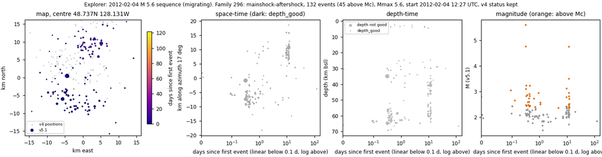

Explorer 2012-02-04 M 5.6 sequence (family 296).

## JdF ridge/plate

#### What the v5.1 locations change

2,851 rows, 2,843 located (8 without a hypocentre, left out), 0 flagged non-earthquakes. Tiers A/B/C/D: 0/0/34/65%. floor_limited 1,173, far_only 11, deep_pass 15; depth_good (tier A-C, depth_quality ok, no flag) 0. Median depth of located earthquakes: v4 5.1 km, v5.1 3.3 km bsl (0.8 km below the surface); median shift 4.5 km horizontally, +3.3 km in depth. Median sig_z 13.3 km, nearest station 35 km. In v4, 43% of these events plot above the ground or seafloor if v4 depth is read as km bsl.

Depth is not constrained on the Juan de Fuca ridge and plate. 1,173 of 2,843 events are floor_limited and 1,049 are within 0.25 km of the seafloor, while 908 are more than 8 km below it (crust 6.7-8 km thick). The median (0.8 km below the seafloor) is the mean of two boundaries, not a depth. Tier A and B are almost absent (0% and 0.2%).

#### Faults: which are active and how

v1 surfaces with most of their members here: 2 (2 steep, 122 fit members; v0: 1 surfaces, 121 members). Stable under the builder's detection reruns: 1; recovered on the verifier's 80% subsample: 1; on tiers A-B only: 0. Of the 2,637 located earthquakes in fitted boxes, 16% are fit members or assigned (loose), 1 are ambiguous and 2,202 are on no surface; 4% are on a surface by the strict rule (on_surface_strict). Median RMS scatter of members about their surface: v0 0.73 km, v1 0.73 km. v1_BL018 keeps the v0 match to the Cleft segment of the southern Juan de Fuca Ridge (ridge-parallel strike 199°); v1_ON026 (49 events, new) lies on the ridge near 45.4°N, 130.0°W.

**v1 surfaces with most members in this region**

| surface | events | strike | dip | depth km | depth ok | stable (reruns) | J 80% subsample | % bg | % swarm | v0 link | members dz v4->v5.1 | literature (carried from v0) | flags (faults piece, shortened) | notes added here |
| --- | --- | --- | --- | --- | --- | --- | --- | --- | --- | --- | --- | --- | --- | --- |
| v1_BL018 | 73 | 198.0 | 86.0 | 4.4 | 26.0 | False | 0.39 | 60.0 | 20.0 | matched | +2.9 | Cleft segment, southern Juan de Fuca Ridge (ridge-parallel structure) | depth poorly constrained; above surface; unstable; not recovered 2/2 |  |
| v1_ON026 | 49 | 207.0 | 56.0 | 3.7 | 0.0 | True | 0.97 | 21.0 | 48.0 | new |  |  | depth poorly constrained; above surface; not recovered 1/2 |  |

#### Sequences, swarms and background

931 earthquakes above Mc: 57% background, 12% in mainshock-aftershock families, 18% in swarms, 13% in multiplets (v4: 58% / 13% / 15% for background / MA / swarm). Families of 5 or more above Mc led by an event here: mainshock-aftershock 4, swarms 18. Tier D events are 60% of the analysis set here, and 71% of them are background (tiers A-C: 36%). 60% of the events above Mc here are tier D, so the class split is as uncertain as at Axial.

#### Swarm and sequence characteristics

Eighteen swarms of 5 or more events above Mc; for 17 the nearest PB2002 step is a ridge step (median 14 km away). The largest are on the southern Endeavour / northern Juan de Fuca section at 47.57-47.64°N: family 1066 (2014-01-09, 146 events, 7.9 km extent, 98 days in all, axis 25°) and family 1003 (2013-11-24, 42 events, new in v5.1). Their epicentres line up with the ridge trend; their depths are pinned at the seafloor (v4 put them at 12-16 km). None is resolvable for migration.

**Largest families led by an event in this region**

| family | type | start (UTC) | events (>=Mc) | Mmax | t90 days | extent km | good-depth median km | n good | resolvable spread | migrating | on surfaces | main surface | nearest boundary | v4 status |
| --- | --- | --- | --- | --- | --- | --- | --- | --- | --- | --- | --- | --- | --- | --- |
| 1066 | swarm | 2014-01-09 19:58 | 146 (30) | 3.9 | 6.1 | 7.9 |  | 0 | False | False | 0.0 |  | OTF 19 km | kept |
| 1003 | swarm | 2013-11-24 05:19 | 42 (5) | 2.7 | 4.1 | 1.6 |  | 0 | False | False | 0.0 |  | OSR 22 km | new |
| 385 | mainshock-aftershock | 2012-08-19 08:07 | 33 (21) | 5.6 | 0.9 | 29.8 |  | 0 | True | False | 0.0 |  | OTF 21 km | kept |
| 879 | swarm | 2013-09-04 01:06 | 31 (21) | 3.3 | 78.2 | 15.7 |  | 0 | False | False | 32.0 | v1_ON026 | OSR 15 km | merged |
| 892 | swarm | 2013-09-11 04:55 | 27 (20) | 3.0 | 1.6 | 12.9 |  | 0 | False | False | 0.0 |  | OSR 38 km | kept |
| 923 | mainshock-aftershock | 2013-10-06 11:40 | 13 (5) | 3.1 | 0.3 | 5.5 |  | 0 | False | False | 0.0 |  | OSR 13 km | kept |

#### Against published studies

Indirect constraints only (magma-chamber reflectors at 2.0-2.7 km below the seafloor; crust 6.7-8 km; Carbotte et al. 2008; Canales et al. 2005). Neither v4 nor v5.1 depths can be compared.

#### v4-era interpretations that no longer hold

- v4 depths of the 2013-2014 ridge swarms (12-16 km): not supported; v5.1 pins them at the seafloor, which is not a measurement either.

**Uncertainty.** Report epicentres only.

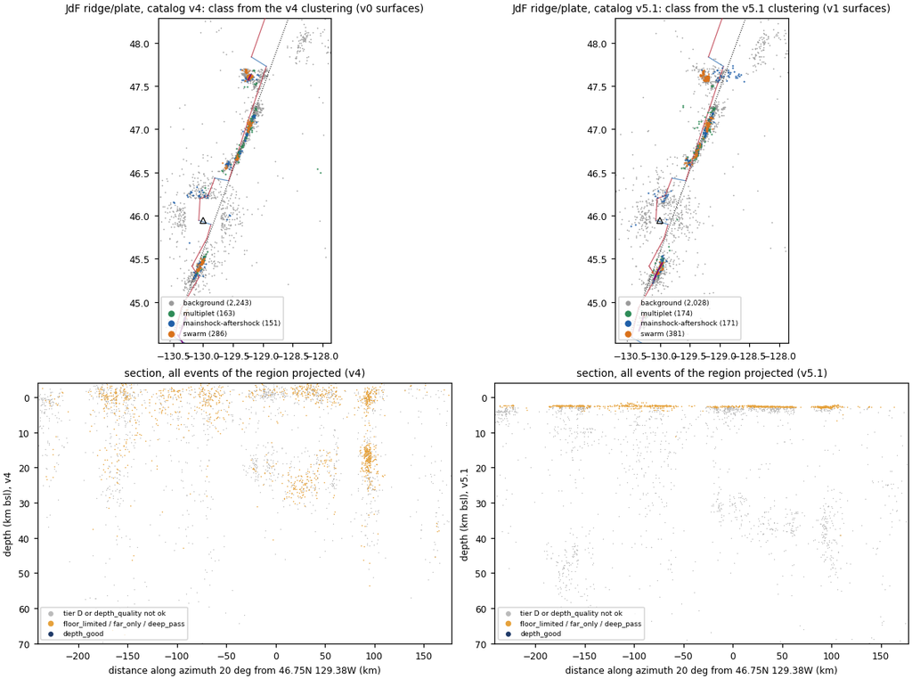

Juan de Fuca ridge and plate: v4 and v5.1 maps and sections (along 20°).

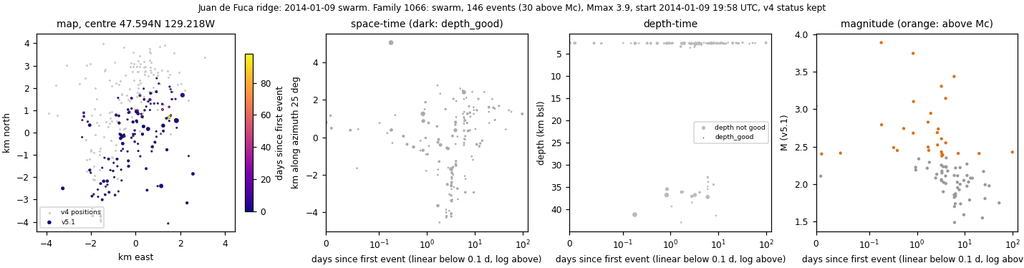

Juan de Fuca ridge 2014-01-09 swarm (family 1066).

## Blanco

#### What the v5.1 locations change

42,385 rows, 42,349 located (36 without a hypocentre, left out), 0 flagged non-earthquakes. Tiers A/B/C/D: 2/8/68/22%. floor_limited 1,046, far_only 286, deep_pass 13; depth_good (tier A-C, depth_quality ok, no flag) 17,116. Median depth of located earthquakes: v4 9.2 km, v5.1 9.3 km bsl (6.3 km below the surface); median shift 1.6 km horizontally, +4.3 km in depth. Median sig_z 7.0 km, nearest station 23 km. In v4, 21% of these events plot above the ground or seafloor if v4 depth is read as km bsl.

The regional median hardly moved (9.2 to 9.3 km bsl), but the segments moved differently (depth_good events, km below the seafloor, v4 read as bsl / v5.1): West 5.5 / 5.5; Surveyor 2.1 / 5.5; Cascadia Depression 7.3 / 4.5; Blanco Ridge 4.9 / 11.6 (p90 21); Gorda Depression 4.4 / 10.9. The eastern segments went 6-7 km deeper. Against the Lange et al. (2026) OBS catalog, event by event (tiers A-C, Lange read as bsl): +1.4 km overall, +2.5 km West, +0.7 km Surveyor, -1.0 km Cascadia Depression, +2.9 km Blanco Ridge (p90 +13 km) and +5.6 km Gorda Depression (paired_v5.1.md). The X9-year tier A-B events are at a median 8.2 km below the seafloor (p10-p90 4.8-16.0).

The sections show columns down to 30-40 km on the Blanco Ridge and horizontal bands at integer depths. A local spike test (events within 0.1 km of a depth against the bins 0.3 km either side) finds spikes at most integer depths from 12 to 20 km, whether or not the depth is a node of model v0.3.1: 12 km (node, ratio 6.8), 15 (node, 3.5), 16 (3.0), 17 (2.1), 18 (node, 2.5), 19 (3.3) and 20 km (2.3); half-integer depths give a median of 1.0. The peak 0.05 km bins are 11.95-12.00, 14.95-15.00 and 18.95-19.00 km, where the Earth-flattening transform puts integer depth nodes of the NonLinLoc travel-time grids, so the likely cause is the 1 km grid lattice, not the linear interpolation of the model; only the 12 km spike stands out at a model node. The first build called these "node pile-ups"; that is corrected here. Depth_quality is "unconstrained" outside the 2012-13 X9 deployment (20,404 events), so 2014-2015 Blanco depths are epicentre-only. 19% of Blanco events share their exact epicentre with another event.

#### Faults: which are active and how

v1 surfaces with most of their members here: 18 (18 steep, 24,323 fit members; v0: 20 surfaces, 18,352 members). Stable under the builder's detection reruns: 7; recovered on the verifier's 80% subsample: 0; on tiers A-B only: 0. Of the 42,349 located earthquakes in fitted boxes, 64% are fit members or assigned (loose), 11,749 are ambiguous and 3,490 are on no surface; 59% are on a surface by the strict rule (on_surface_strict). Median RMS scatter of members about their surface: v0 0.69 km, v1 0.74 km.

**v1 surfaces with most members in this region**

| surface | events | strike | dip | depth km | depth ok | stable (reruns) | J 80% subsample | % bg | % swarm | v0 link | members dz v4->v5.1 | literature (carried from v0) | flags (faults piece, shortened) | notes added here |
| --- | --- | --- | --- | --- | --- | --- | --- | --- | --- | --- | --- | --- | --- | --- |
| v1_BL001 | 5180 | 296.0 | 90.0 | 10.7 | 57.0 | False |  | 32.0 | 52.0 | split and merged | +4.0 | BL004b: West Blanco Depression transform zone, N member of the 2 km pair with BL004a \| BL0 | above surface; strand dip set by band; unstable |  |
| v1_BL002 | 4369 | 116.0 | 90.0 | 10.7 | 54.0 | False |  | 44.0 | 38.0 | split and merged | +3.0 | BL006a: Surveyor Depression N-wall strand, continuing W into the EBD \| BL004a: West Blanco | above surface; strand dip set by band; unstable |  |
| v1_BL003 | 2369 | 113.0 | 90.0 | 10.1 | 70.0 | True |  | 69.0 | 9.0 | matched | +4.5 | Surveyor Depression S-wall strand | strand dip set by band |  |
| v1_BL004 | 2357 | 121.0 | 68.0 | 10.4 | 51.0 | False | 0.04 | 47.0 | 19.0 | merged | -0.5 | BL008: Cascadia Depression N–S normal fault (parallel to BL005) \| BL021: Cascadia Depressi | unstable; not recovered 3/3 |  |
| v1_BL005 | 2200 | 113.0 | 89.0 | 16.2 | 69.0 | True |  | 55.0 | 18.0 | split | +8.3 | Blanco Ridge transform (principal, crustal strand) | strand dip set by band |  |
| v1_BL006 | 1654 | 316.0 | 65.0 | 7.8 | 55.0 | False | 0.13 | 49.0 | 28.0 | matched | +0.2 | Western tip of the Blanco Ridge, N-shifted strand next to CAS | unstable; not recovered 3/3 |  |
| v1_BL007 | 1341 | 116.0 | 90.0 | 10.8 | 55.0 | False |  | 54.0 | 24.0 | matched | +4.9 | Third (intra-basin) strand inside the Surveyor Depression | above surface; strand dip set by band; unstable |  |
| v1_BL008 | 1039 | 117.0 | 89.0 | 15.9 | 45.0 | False |  | 64.0 | 14.0 | split and merged | +7.3 | BL014a: Gorda Depression intra-basin transtensional strand (central GD clusters), extendin | depth poorly constrained; above surface; strand dip set by band; unstable |  |
| v1_BL009 | 877 | 113.0 | 88.0 | 23.1 | 32.0 | True |  | 52.0 | 16.0 | split | +7.6 | Blanco Ridge transform (principal, crustal strand) | depth poorly constrained; deep centroid; strand dip set by band |  |
| v1_BL010 | 726 | 345.0 | 86.0 | 17.9 | 48.0 | False | 0.08 | 45.0 | 9.0 | matched | +0.2 | Cascadia Depression N–S normal fault (deeper image of BL005) | depth poorly constrained; unstable; not recovered 3/3 |  |
| v1_BL011 | 532 | 302.0 | 90.0 | 16.0 | 59.0 | True |  | 74.0 | 0.0 | split and merged | +6.2 | BL016a: Gorda Depression N wall, S member \| BL014a: Gorda Depression intra-basin transtens | above surface; strand dip set by band |  |
| v1_BL012 | 424 | 152.0 | 86.0 | 26.6 | 44.0 | False | 0.17 | 43.0 | 23.0 | new | +5.9 |  | depth poorly constrained; deep centroid; unstable; not recovered 3/3 |  |
| v1_BL013 | 339 | 300.0 | 90.0 | 18.0 | 49.0 | True |  | 77.0 | 0.0 | split and merged | +7.3 | BL016a: Gorda Depression N wall, S member \| BL016b: Gorda Depression N wall (SE continuati | depth poorly constrained; strand dip set by band |  |
| v1_BL014 | 295 | 116.0 | 89.0 | 14.7 | 42.0 | True |  | 39.0 | 38.0 | split and merged | -1.9 | BL015a: WBD near the RTI: S branch of Lange's two parallel clusters at the JdF intersectio | depth poorly constrained; above surface; strand dip set by band |  |

#### Sequences, swarms and background

7,227 earthquakes above Mc: 52% background, 12% in mainshock-aftershock families, 26% in swarms, 10% in multiplets (v4: 50% / 18% / 22% for background / MA / swarm). Families of 5 or more above Mc led by an event here: mainshock-aftershock 35, swarms 69. Tier D events are 8% of the analysis set here, and 73% of them are background (tiers A-C: 51%).

By segment (events above Mc): West 45% in swarms and 40% background; Surveyor 11% / 65%; Cascadia Depression 19% / 48%; Blanco Ridge 14% / 60%; Gorda Depression 0% / 80%. The swarm-rich part of the transform is the West Blanco Depression; the Blanco Ridge and the Gorda Depression are mostly background with a few mainshock-aftershock families. The BL clustering box is the most robust of the swarm-rich settings: shuffled catalogs reproduce 39% of its links (Axial 75%) and 62% when times are shuffled within the month (the lowest of the nine boxes, which range from 62% to 92%); shuffles form 12.8 swarms against 70 real ones; removing tier D changes its background share by 1.7 points. These are numbers for the whole BL box; no null test was run on the West Blanco Depression alone. The two large Blanco multiplets are still swarms with M1-M2 near 0.1 (2012-02/04 Mw 5.8 and 6.0; 2015-06-01 Mw 5.8, 5.4 and 5.9), as at other oceanic transforms (McGuire et al. 2005; Boettcher & McGuire 2009). The stored offshore ML is above ComCat ML at Blanco (anchor median +0.33; +0.59 on anchors with at least 3 near picks); the magnitude piece found its phase19 inversion unconverged, and the converged solution lowers Blanco ML by a median 0.68 (gap to ComCat +0.10). A regional shift moves Mc and the set of events above it, not M1-M2.

#### Swarm and sequence characteristics

69 swarms of 5 or more events above Mc; for 67 the nearest PB2002 step is a transform step (median 30 km away); median t90 4.2 hours, median extent 4.3 km, median good-depth 8.3 km bsl. Nine have a resolvable spread and none migrates by the test. The 2012-10-02 swarm on the West Blanco Depression (family 427, 1,447 events, 683 above Mc, Mmax 4.9) is the largest family of the catalog. It occupies a 16 km patch of v1_BL001 (75% of its events on surfaces, strict join) within 3.4 days at the 90% level, with no ordered spreading (rho 0.03). Its good depths span 5-21 km (p10-p90), wider than the 0-8 km published for the western segments (Ren et al. 2023; Adimah et al. 2024), with bands at integer depths (strongest at 12 km); the depth range is location scatter, not a fault 16 km tall. The 2015-06-01 triplet (family 1932, 744 events) covers about 21 km of the West Blanco Depression within 13 hours: the Mw 5.8 at 06:52 UTC, the Mw 5.4 3.9 hours later 7 km ESE of it, and the Mw 5.9 13 hours later 14 km WNW of it, i.e. three adjacent patches, as at other oceanic transforms. During days 1-10 the activity reaches 30 km further WNW; after day 10 it returns to a 15 km patch around the first event. Its depths are not constrained (2015, outside the X9 year). The 2014-03-11/12 sequence (family 1170, 480 events) was a mainshock-aftershock family in v4 (1,274 events) and is now a swarm of 480 events, because the tighter epicentres of v5.1 cut its links to neighbouring bursts; the DBSCAN scan shows the reverse effect, chaining four 2013 bursts into one cluster longer than 30 days.

**Largest families led by an event in this region**

| family | type | start (UTC) | events (>=Mc) | Mmax | t90 days | extent km | good-depth median km | n good | resolvable spread | migrating | on surfaces | main surface | nearest boundary | v4 status |
| --- | --- | --- | --- | --- | --- | --- | --- | --- | --- | --- | --- | --- | --- | --- |
| 427 | swarm | 2012-10-02 11:47 | 1447 (683) | 4.9 | 3.4 | 16.5 | 8.2 | 1241 | True | False | 75.0 | v1_BL001 | OTF 39 km | kept |
| 1932 | swarm | 2015-06-01 06:52 | 744 (101) | 5.9 | 31.9 | 46.3 |  | 0 | True | False | 69.0 | v1_BL002 | OTF 22 km | kept |
| 1170 | swarm | 2014-03-12 04:17 | 480 (192) | 4.3 | 4.3 | 9.3 |  | 0 | False | False | 63.0 | v1_BL001 | OTF 37 km | changed |
| 1453 | mainshock-aftershock | 2014-11-23 03:25 | 362 (53) | 5.2 | 1.8 | 13.1 |  | 0 | True | False | 63.0 | v1_BL010 | OTF 41 km | kept |
| 1268 | mainshock-aftershock | 2014-05-12 16:45 | 195 (48) | 5.3 | 3.8 | 13.9 |  | 0 | True | False | 15.0 | v1_BL004 | OTF 23 km | kept |
| 302 | swarm | 2012-02-15 03:31 | 163 (96) | 6.0 | 225.6 | 50.2 | 12.9 | 49 | True | False | 72.0 | v1_BL005 | OTF 29 km | kept |

#### Against published studies

Agrees: segment layout and the swarm-rich western transform with burst-like seismicity (Lange et al. 2026, bursts shorter than 5 minutes; Journeau et al. 2026, more events at step-overs). Agrees within about 1 km at Surveyor and in the Cascadia Depression. Disagrees on the Blanco Ridge and in the Gorda Depression: v5.1 good depths have medians of 11-12 km below the seafloor against crustal events at 3-7 km and mantle events at 8-13 km (Kuna et al. 2019) and a maximum of about 10-14 km (Liu & Tan 2025; Lange et al. 2026). The question of mantle swarms on the Blanco Ridge (Kuna et al. 2019) cannot be answered with v5.1 depths, because the events that would carry it are the ones with the +3 to +13 km offset.

#### v4-era interpretations that no longer hold

- v0 Blanco 'deeper band' (merged strands): reappears as v1_BL009/BL015 on events with unconstrained depth; still not a fault.
- v0 Cascadia Depression N-S faults: not recovered in v1 because of detection order; the v0 interpretation is neither confirmed nor refuted by v1.
- v4 2014-03-11 mainshock-aftershock family (1,274 events): now a 480-event swarm; family membership at Blanco depends on epicentre precision.
- v4 'vertical columns where depth is poorly constrained': still present, now deeper on the Blanco Ridge, plus spikes at integer depths (1 km grid lattice; strongest at 12 km).

**Uncertainty.** Depths outside the 2012-13 X9 year are unconstrained; within it, Blanco Ridge and Gorda Depression depths are 3-6 km too deep at the median.

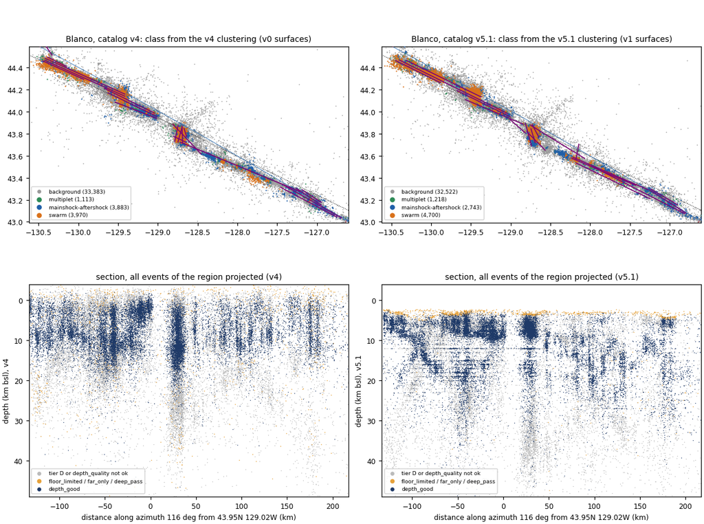

Blanco: v4 and v5.1 maps and sections along the transform (116°).

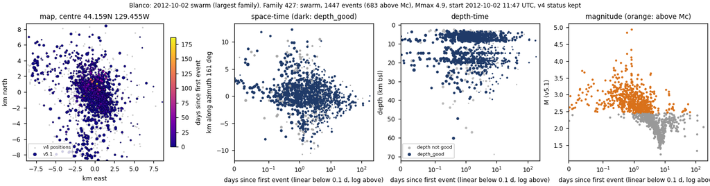

Blanco 2012-10-02 swarm (family 427).

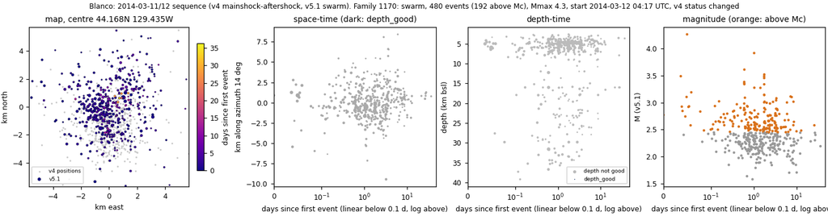

Blanco 2014-03-11/12 sequence (family 1170).

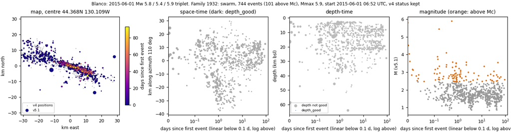

Blanco 2015-06-01 Mw 5.8/5.4/5.9 triplet (family 1932).

## Gorda

#### What the v5.1 locations change

11,380 rows, 11,352 located (28 without a hypocentre, left out), 0 flagged non-earthquakes. Tiers A/B/C/D: 4/22/49/25%. floor_limited 345, far_only 214, deep_pass 15; depth_good (tier A-C, depth_quality ok, no flag) 1,506. Median depth of located earthquakes: v4 21.2 km, v5.1 24.7 km bsl (21.7 km below the surface); median shift 3.5 km horizontally, +4.7 km in depth. Median sig_z 6.6 km, nearest station 31 km. In v4, 22% of these events plot above the ground or seafloor if v4 depth is read as km bsl.

The Gorda depths split by station distance. All interior events (127-125°W, 40.5-42.5°N; 6,187) are at a median 22 km below the seafloor, 7-13 km below the thermal limit for faulting in 4 Myr lithosphere (9.5-15 km below the seafloor; VanderBeek & Toomey 2019). The 542 interior events with a station within 10 km are at a median 8.3 km below the seafloor, inside the limit. The catalog flags the rest as biased_deep (9,188 of 11,352), and the near-station subset shows why. Near the ridge axis the same pattern holds (tier A-B within 10 km of the PB2002 ridge: 21 km below the seafloor on 51 events, 12 km on the 33 with a station within 15 km, against 3-7 km in Jones & Johnson 1978). Against ANSS (mostly NCSN and USGS), v5.1 is +7 to +9 km deeper, depending on the matcher: +9.4 km on 207 events with this report's match (3 s, 20 km, fixed depths removed; v4 +4.0 km), +9.4 km when every round ANSS depth (0, 5, 6, 10, 33, 35 km) is dropped, and +7.2 km on 155 events with the verifier's mutual-nearest 2 s / 15 km match (v4 +3.4 km). The depth_good events moved from a v4 median of 1.3 km to 15.9 km bsl; read as km bsl, the v4 value would be above the seafloor (about 3 km deep), another sign of the v4 datum problem. Depths spike at 29 km (a model node, ratio 3.3) but as much at 30 km (3.0) and 37 km (2.3), which are not nodes: this is the 1 km grid lattice described under Blanco, not a node effect.

#### Faults: which are active and how

v1 surfaces with most of their members here: 28 (21 steep, 5,256 fit members; v0: 21 surfaces, 2,988 members). Stable under the builder's detection reruns: 6; recovered on the verifier's 80% subsample: 6; on tiers A-B only: 2. Of the 11,352 located earthquakes in fitted boxes, 58% are fit members or assigned (loose), 2,381 are ambiguous and 2,374 are on no surface; 48% are on a surface by the strict rule (on_surface_strict). Median RMS scatter of members about their surface: v0 1.12 km, v1 1.18 km.

The ridge-axis surfaces keep their v0 literature matches but are mostly unstable: v1_GO002 (Jackson segment of the Gorda Ridge, strike 22°, dip 43°, 562 events, 39% of its events above Mc in swarms) and v1_GO004 (northern Escanaba Trough axis, 363 events, 36%; members moved +14.8 km in depth). The 2014-03-10 Mw 6.8 rupture zone in the plate interior is imaged by v1_MT009, v1_MT013 and v1_MT017 (NE strike, near-vertical, 0-2% depth-ok members): their traces agree with the NE-striking left-lateral faults of the Gorda deformation zone (Chaytor et al. 2004), but their depths (26-27 km) are in the biased_deep population. The faults piece now flags 17 surfaces whose members moved more than 10 km in depth from v4 to v5.1; 10 are in Gorda (GO004, GO008, GO009, GO012, GO014, GO016, GO019, GO020, GO023, GO024; e.g. v1_GO008 +15.5 km, v1_GO023 +17.3 km). Their depths are not confirmed: v5.1 events with ComCat moment tensors are a median 13.7 km deeper than ComCat (waveform review P3).

**v1 surfaces with most members in this region**

[output not shown]

#### Sequences, swarms and background

2,637 earthquakes above Mc: 41% background, 49% in mainshock-aftershock families, 5% in swarms, 5% in multiplets (v4: 41% / 49% / 6% for background / MA / swarm). Families of 5 or more above Mc led by an event here: mainshock-aftershock 14, swarms 11. Tier D events are 11% of the analysis set here, and 73% of them are background (tiers A-C: 37%).

The Gorda region is the clearest two-setting region. Near the ridge (within 15 km of a PB2002 ridge step; 174 events above Mc) 14% of the events are in swarms and 22% in mainshock-aftershock families; in the interior (2,463) the shares are 5% and 51%, driven by the 2014 Mw 6.8 sequence. Among the Gorda box's families of 5 or more, 48% are swarms (v4 65%, on 25 families). Swarm families are shallower than mainshock-aftershock families (family medians 9.1 against 25.3 km on 8 and 17 families, Mann-Whitney p = 0.004, 0.027 after a Bonferroni correction over 7 regions; clustering piece). GO is the only box where the difference survives the correction (MT p = 0.016 and ON 0.019 are nominal only). Most Gorda depths are biased_deep, so this rests on 125 depth_good swarm events, 27% of them in one family.

#### Swarm and sequence characteristics

Eleven swarms of 5 or more events above Mc; for all of them the nearest PB2002 step is a ridge step (median 22 km away; PB2002 traces are coarse). The 2013-05-20 Escanaba Trough swarm (family 736, 54 events, Mmax 4.0) runs 10 km along the axis (169°) with a good-depth median of 12 km bsl (about 9 km below the seafloor). v4 reported it migrating at about 10 km/day; in v5.1 its rho is 0.46, below the test, so a dike-like migration is no longer supported. The 2013-11-13 swarm (family 989, 19 events, 16 tier A-C) passes the test with about 40 km/day over 9 hours (permutation p = 0.0045 in the clustering piece, 0.0034 in the verifier's run), but not after a Bonferroni correction over the 67 resolvable families (p < 0.00075), on 16 events with a median horizontal error of 3.8 km and depths of 33-36 km that are not physical for the ridge; treat it as a candidate only.

**Largest families led by an event in this region**

| family | type | start (UTC) | events (>=Mc) | Mmax | t90 days | extent km | good-depth median km | n good | resolvable spread | migrating | on surfaces | main surface | nearest boundary | v4 status |
| --- | --- | --- | --- | --- | --- | --- | --- | --- | --- | --- | --- | --- | --- | --- |
| 1162 | mainshock-aftershock | 2014-03-10 01:58 | 2358 (1239) | 6.8 | 71.5 | 134.1 | 19.0 | 377 | True | False | 67.0 | v1_MT009 | SUB 23 km | kept |
| 1174 | mainshock-aftershock | 2014-03-13 19:11 | 84 (12) | 5.5 | 289.5 | 22.0 | 19.7 | 31 | False | False | 68.0 | v1_GO014 | OSR 12 km | kept |
| 1498 | mainshock-aftershock | 2014-12-18 15:32 | 56 (12) | 4.6 | 0.8 | 11.8 | 16.2 | 37 | True | False | 79.0 | v1_GO008 | OSR 22 km | kept |
| 736 | swarm | 2013-05-20 02:11 | 54 (37) | 4.0 | 3.8 | 10.0 | 12.1 | 34 | True | False | 76.0 | v1_GO004 | OSR 13 km | kept |
| 1015 | mainshock-aftershock | 2013-12-01 02:39 | 45 (19) | 5.5 | 1.2 | 18.3 |  | 0 | True | False | 67.0 | v1_GO012 | OSR 13 km | kept |
| 1647 | swarm | 2015-02-26 04:49 | 41 (9) | 3.3 | 0.5 | 5.0 | 24.2 | 21 | True | False | 66.0 | v1_GO014 | OSR 22 km | kept |

#### Against published studies

Agrees: the near-station interior depths (8 km below the seafloor) with the thermal limit and the 9-10 km seismogenic thickness (Rollins & Stein 2010); NE trends in the interior with Chaytor et al. (2004). Disagrees: all-station interior and ridge depths, too deep by 7-15 km. The deepening away from the ridge reported by Ren et al. (2025, abstract; same OBS data and picks) has the same signature as our station-distance bias and is not an independent check.

#### v4-era interpretations that no longer hold

- v4 'Gorda plate median depth 21.5 km' and slab-versus-plate questions based on it: the bulk of that depth is a station-distance bias; near-station events are at 8-11 km below the seafloor.
- v4 2013-05-20 Escanaba swarm 'migrates at about 10 km/day': not supported in v5.1.
- v4 '65% of families are swarms': 48% in v5.1 (25 families).

**Uncertainty.** Use only events with a station within 10-15 km for depth statements; 81% of located events are biased_deep.

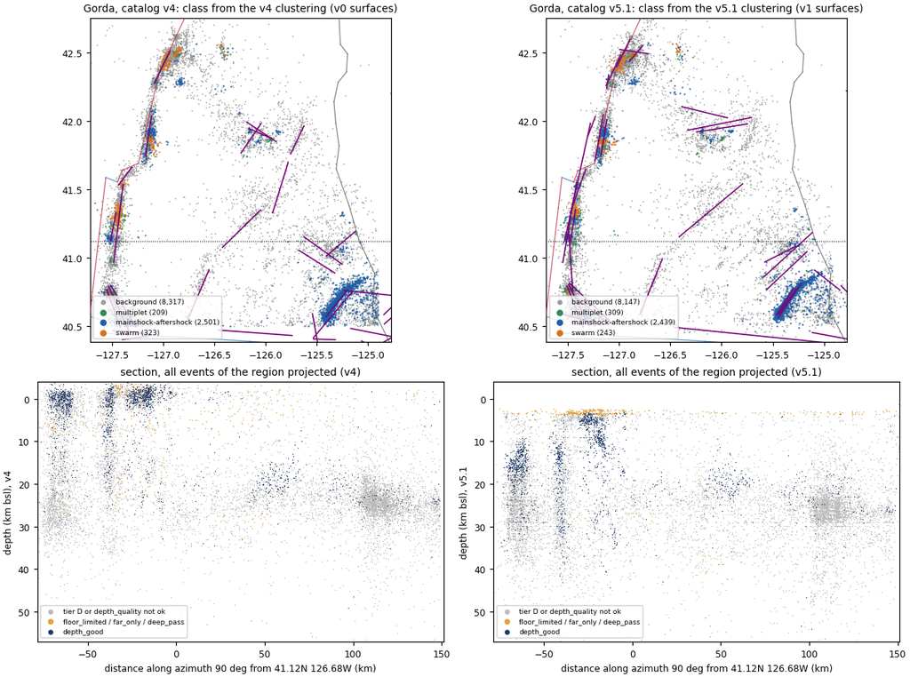

Gorda: v4 and v5.1 maps and sections along 90°.

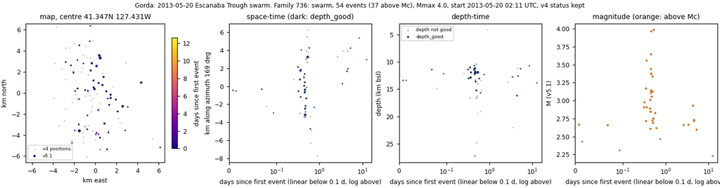

Gorda 2013-05-20 Escanaba Trough swarm (family 736).

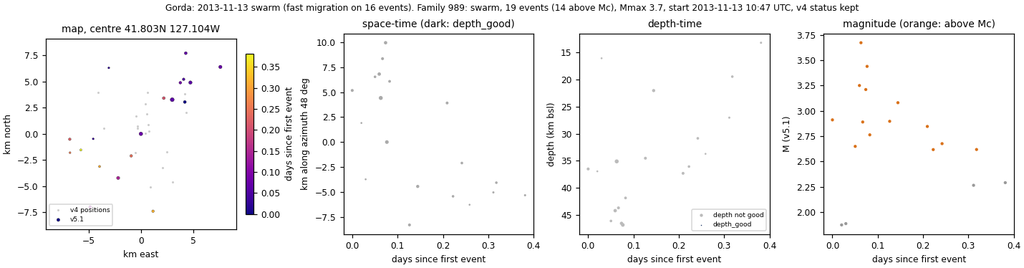

Gorda 2013-11-13 swarm (family 989).

## Mendocino

#### What the v5.1 locations change

24,644 rows, 24,608 located (36 without a hypocentre, left out), 0 flagged non-earthquakes. Tiers A/B/C/D: 22/20/31/28%. floor_limited 448, far_only 50, deep_pass 25; depth_good (tier A-C, depth_quality ok, no flag) 17,690. Median depth of located earthquakes: v4 21.1 km, v5.1 23.4 km bsl (23.0 km below the surface); median shift 1.8 km horizontally, +2.7 km in depth. Median sig_z 2.9 km, nearest station 14 km. In v4, 5% of these events plot above the ground or seafloor if v4 depth is read as km bsl.

The Mendocino triple junction is well recorded (22% tier A, depth_quality ok everywhere) and v5.1 moved it deeper. Against ANSS/ComCat (nc; fixed depths removed), on 1,740 events matched in both versions, our depth minus ANSS is +1.5 km in v4 and +3.6 km in v5.1 (median |difference| 2.7 and 3.8 km). The depth-literature report found the same 2-4 km offset onshore and near shore against NCSN and the slab literature (Ferndale aftershocks at 17-20 km, Shelly et al. 2024; double zone at 15-25 km, Wang & Rogers 1994). The double seismic zone is still visible in the depth_good events but sits about 3 km deeper: modes at about 23.5 and 28.5 km in v5.1 against 20.5 and 25 km in v4. The modes are broad (0.5 km bins). The spike ratio at the 29 km model node is 1.6 in Mendocino, no larger than at 37 km (2.4), which is not a node, so the lower mode is not a node artefact as far as this test shows.

#### Faults: which are active and how

v1 surfaces with most of their members here: 17 (7 steep, 14,910 fit members; v0: 17 surfaces, 11,710 members). Stable under the builder's detection reruns: 2; recovered on the verifier's 80% subsample: 4; on tiers A-B only: 0. Of the 24,608 located earthquakes in fitted boxes, 65% are fit members or assigned (loose), 5,305 are ambiguous and 3,290 are on no surface; 57% are on a surface by the strict rule (on_surface_strict). Median RMS scatter of members about their surface: v0 1.23 km, v1 1.34 km.

Most Mendocino surfaces are dipping layers (dip 31-43°) within the upper Gorda slab: v1_MT002, MT003, MT004 and MT006 (1,000-2,700 events each, 70-76% background) are pieces of one slab-top layer that the detection splits differently from run to run (none is recovered on the 80% subsample except MT003 at J = 0.56). The steep surfaces that keep a clear match are the Mendocino transform segment at 125.7-126.5°W (v1_GO001, strike 276°, vertical, 966 events, members moved +3.8 km) and the Garberville swarm volume (v1_MT010 and v1_MT011, both stable and recovered).

**v1 surfaces with most members in this region**

| surface | events | strike | dip | depth km | depth ok | stable (reruns) | J 80% subsample | % bg | % swarm | v0 link | members dz v4->v5.1 | literature (carried from v0) | flags (faults piece, shortened) | notes added here |
| --- | --- | --- | --- | --- | --- | --- | --- | --- | --- | --- | --- | --- | --- | --- |
| v1_MT002 | 2708 | 224.0 | 40.0 | 22.9 | 100.0 | False | 0.42 | 74.0 | 1.0 | matched | +1.2 | Same upper-slab layer (duplicate of MT004/MT006). | unstable; not recovered 3/3 |  |
| v1_MT003 | 2417 | 252.0 | 34.0 | 24.1 | 100.0 | False | 0.56 | 70.0 | 0.0 | new | +2.7 |  | unstable; not recovered 2/3 |  |
| v1_MT004 | 1537 | 218.0 | 39.0 | 21.4 | 100.0 | False | 0.48 | 70.0 | 1.0 | matched | +1.9 | Upper-plate seismicity above the 1992 rupture, at the junction of the Garberville–Bricelan | unstable; not recovered 3/3 |  |
| v1_MT005 | 1528 | 137.0 | 34.0 | 25.2 | 96.0 | False | 0.17 | 66.0 | 0.0 | matched | +2.6 | Southern Gorda slab next to the near-shore MFZ: lower (mantle) layer of the double seismic | unstable; not recovered 3/3 |  |
| v1_MT006 | 1032 | 216.0 | 36.0 | 24.9 | 100.0 | False | 0.12 | 76.0 | 0.0 | matched | +3.3 | Gorda slab top / interface-proximal seismic layer beneath Rio Dell–Scotia. | unstable; not recovered 3/3 |  |
| v1_MT007 | 979 | 155.0 | 31.0 | 18.6 | 92.0 | False | 0.17 | 46.0 | 5.0 | new | +0.3 |  | unstable; not recovered 3/3 |  |
| v1_GO001 | 966 | 276.0 | 90.0 | 27.5 | 99.0 | False | 0.49 | 77.0 | 0.0 | merged | +3.8 | GO001: Mendocino transform, segment at 125.7–126.5°W that ruptured in the 2016-12-08 Mw 6. | unstable; not recovered 3/3 |  |
| v1_MT008 | 862 | 278.0 | 85.0 | 24.0 | 100.0 | False | 0.07 | 65.0 | 0.0 | split | +1.9 | Same volume. May image the south-dipping southern edge of the Gorda slab against the MFZ. | unstable; not recovered 3/3 |  |
| v1_MT010 | 653 | 113.0 | 77.0 | 26.8 | 100.0 | True | 0.62 | 79.0 | 0.0 | matched | +3.8 | Garberville swarm volume: steep SSW-dipping companion to MT009. Possibly the fluid-assiste | not recovered 2/3 |  |
| v1_MT011 | 607 | 312.0 | 43.0 | 23.4 | 100.0 | True | 0.60 | 64.0 | 0.0 | split | +3.3 | "Garberville swarm" / Mendocino LFE plane: the buried eastward continuation of the Mendoci | not recovered 2/3 |  |
| v1_MT014 | 453 | 116.0 | 59.0 | 27.7 | 100.0 | False | 0.65 | 41.0 | 0.0 | split | +3.2 | Same volume. May image the south-dipping southern edge of the Gorda slab against the MFZ. | unstable; not recovered 2/3 |  |
| v1_GO003 | 402 | 128.0 | 49.0 | 31.1 | 56.0 | False | 0.45 | 39.0 | 0.0 | new | +6.7 |  | unstable; not recovered 3/3 |  |
| v1_GO007 | 261 | 106.0 | 64.0 | 28.4 | 92.0 | False | 0.34 | 50.0 | 9.0 | merged | +4.5 | GO004: Mendocino transform, westernmost active segment just east of the Escanaba RTI \| GO0 | unstable; not recovered 3/3 |  |
| v1_MT019 | 213 | 267.0 | 40.0 | 21.7 | 100.0 | False | 0.15 | 38.0 | 24.0 | split | +4.3 | "Garberville swarm" / Mendocino LFE plane: the buried eastward continuation of the Mendoci | unstable; not recovered 3/3 |  |

#### Sequences, swarms and background

3,912 earthquakes above Mc: 69% background, 25% in mainshock-aftershock families, 1% in swarms, 5% in multiplets (v4: 70% / 24% / 1% for background / MA / swarm). Families of 5 or more above Mc led by an event here: mainshock-aftershock 23, swarms 7. Tier D events are 17% of the analysis set here, and 65% of them are background (tiers A-C: 70%).

#### Swarm and sequence characteristics

Seven small swarms (median 14 events), median t90 5 hours, median good depth 20 km, within the slab layers. None migrates.

**Largest families led by an event in this region**

| family | type | start (UTC) | events (>=Mc) | Mmax | t90 days | extent km | good-depth median km | n good | resolvable spread | migrating | on surfaces | main surface | nearest boundary | v4 status |
| --- | --- | --- | --- | --- | --- | --- | --- | --- | --- | --- | --- | --- | --- | --- |
| 1536 | mainshock-aftershock | 2015-01-14 10:38 | 682 (90) | 5.7 | 63.0 | 40.1 | 22.9 | 567 | True | False | 74.0 | v1_MT008 | CCB 3 km | kept |
| 1867 | mainshock-aftershock | 2015-04-24 01:34 | 374 (20) | 5.4 | 10.8 | 31.1 | 33.9 | 279 | True | False | 77.0 | v1_GO003 | OTF 11 km | kept |
| 10 | mainshock-aftershock | 2010-02-04 20:20 | 329 (148) | 5.9 | 25.4 | 50.4 | 31.8 | 46 | True | False | 6.0 | v1_MT005 | SUB 7 km | kept |
| 402 | mainshock-aftershock | 2012-09-14 11:53 | 141 (13) | 4.8 | 16.0 | 4.3 | 26.2 | 126 | True | False | 89.0 | v1_MT003 | CCB 38 km | kept |
| 713 | mainshock-aftershock | 2013-05-01 21:03 | 66 (12) | 3.9 | 1.0 | 9.2 | 11.0 | 57 | False | False | 67.0 | v1_MT001 | CCB 16 km | kept |
| 1421 | mainshock-aftershock | 2014-10-19 13:58 | 63 (11) | 4.7 | 36.9 | 2.8 | 22.8 | 59 | True | False | 78.0 | v1_MT014 | CTF 20 km | kept |

#### Against published studies

Agrees: low productivity and high background (Hsu et al. 2026); a double seismic zone (Wang & Rogers 1994; McCrory et al. 2012). Disagrees: absolute depths are 3-4 km deeper than NCSN and the relocated sequences (Shelly et al. 2024; Guo et al. 2025), so assignments of events to slab crust or slab mantle cannot be made from v5.1 depths. Separation within the double zone (about 5 km) can still be used.

#### v4-era interpretations that no longer hold

- v4 depths closer to NCSN (+1.5 km) than v5.1 (+3.6 km): the relocation increased the Mendocino offset; slab-crust versus slab-mantle statements wait on it.
- v4 2010 Mw 6.5 family with the Mw 5.9 aftershock: in v5.1 the Mw 5.9 heads its own family; membership near the threshold is not stable.

**Uncertainty.** Absolute depths +3 to +4 km against NCSN; the separation of the double zone (about 5 km) can be used.

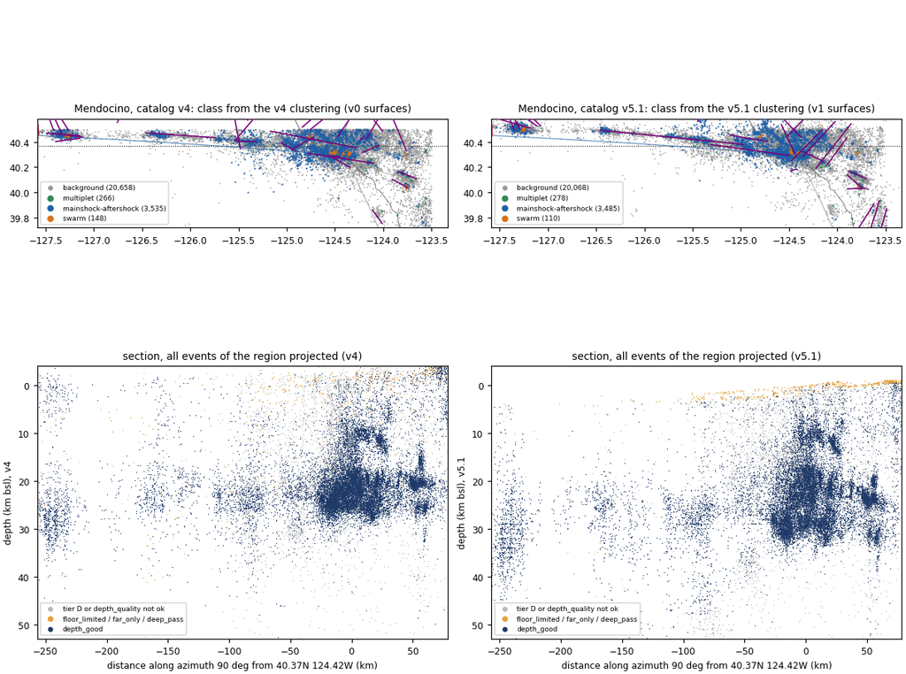

Mendocino: v4 and v5.1 maps and sections along 90°.

## Offshore forearc

#### What the v5.1 locations change

15,422 rows, 15,398 located (24 without a hypocentre, left out), 1,584 flagged non-earthquakes. Tiers A/B/C/D: 10/26/36/28%. floor_limited 442, far_only 30, deep_pass 21; depth_good (tier A-C, depth_quality ok, no flag) 9,402. Median depth of located earthquakes: v4 18.7 km, v5.1 19.6 km bsl (19.7 km below the surface); median shift 2.6 km horizontally, +1.6 km in depth. Median sig_z 4.8 km, nearest station 24 km. In v4, 6% of these events plot above the ground or seafloor if v4 depth is read as km bsl.

The forearc changed little at the median (18.7 to 19.6 km), and the named benchmarks hold: the Fortuna cluster (1,688 tier A-C events within 6 km of 40.6°N 124.1°W) is at a median 19.0 km (p10-p90 16.7-20.4) against 17-23 km (Alongi et al. 2021). Against ANSS/ComCat (uw,nc,us; fixed depths removed), on 895 events matched in both versions, our depth minus ANSS is +1.1 km in v4 and +2.3 km in v5.1 (median |difference| 4.9 and 4.6 km). The region holds 1,584 flagged non-earthquakes, most of them the Texada Island quarry blasts (removed from all statistics here).

Two forearc results need a check before use. The 2012 Brookings swarm (v1_GO022; 39 events at 42.21°N 124.74°W, 33 in 2012) is at a median 52 km in v5.1 (42-65 km) against 20 km in v4, with depth_quality ok, sig_z 7 km and the nearest station 45 km away. Slab2 puts the slab top at about 10 km there (9.4-11.4 km at the members' epicentres, 8.3-12.9 km over the surrounding nodes; the first build quoted 15-20 km), so 52 km is about 42 km below the slab top, and the v4 depth was already about 9 km below it. The waveform review (P2, /wd1/mdenolle_data/catalog_v5/v5.1_review/P2_brookings/) explains the v5.1 depth: predicted S-P is not monotonic with depth in the v5.1 grids, so about 7-9 km and about 56 km both fit the distant stations (KSXB, L02D, L02E), and NonLinLoc took the deep one. v1_ON017 (80 events near 49.4°N 127.2°W off Vancouver Island) moved +15 km to 32 km.

#### Faults: which are active and how

v1 surfaces with most of their members here: 18 (12 steep, 5,348 fit members; v0: 14 surfaces, 5,332 members). Stable under the builder's detection reruns: 8; recovered on the verifier's 80% subsample: 9; on tiers A-B only: 2. Of the 13,814 located earthquakes in fitted boxes, 50% are fit members or assigned (loose), 2,313 are ambiguous and 4,589 are on no surface; 41% are on a surface by the strict rule (on_surface_strict). Median RMS scatter of members about their surface: v0 1.22 km, v1 1.15 km.

**v1 surfaces with most members in this region**

| surface | events | strike | dip | depth km | depth ok | stable (reruns) | J 80% subsample | % bg | % swarm | v0 link | members dz v4->v5.1 | literature (carried from v0) | flags (faults piece, shortened) | notes added here |
| --- | --- | --- | --- | --- | --- | --- | --- | --- | --- | --- | --- | --- | --- | --- |
| v1_MT001 | 3038 | 224.0 | 49.0 | 19.5 | 100.0 | False | 0.60 | 54.0 | 12.0 | matched | +1.0 | Uppermost Gorda slab crust beneath Fortuna: the "Fortuna cluster". This is the volume that | unstable |  |
| v1_MT012 | 475 | 224.0 | 39.0 | 19.3 | 100.0 | False | 0.17 | 40.0 | 0.0 | matched | +1.0 | Gorda slab-mantle seismicity at the 2010-01-10 Mw 6.5 source; probably a low-dip duplicate | unstable; not recovered 3/3 |  |
| v1_MT015 | 444 | 66.0 | 47.0 | 16.2 | 100.0 | False | 0.11 | 69.0 | 0.0 | matched | -1.9 | Upper-plate seismicity beneath the Table Bluff / Little Salmon fold-thrust belt. Geometry | unstable; not recovered 3/3 |  |
| v1_MT016 | 290 | 63.0 | 80.0 | 25.1 | 100.0 | False | 0.18 | 38.0 | 0.0 | matched | +1.1 | 2010-01-10 Mw 6.5 offshore Eureka/Ferndale fault: NE-striking left-lateral fault in the Go | unstable; not recovered 3/3 |  |
| v1_MT018 | 277 | 210.0 | 43.0 | 20.4 | 100.0 | False | 0.05 | 90.0 | 0.0 | merged | -0.9 | MT006: Same upper-slab layer (duplicate). \| MT028: Intraslab NE-trending seismicity (lower | unstable; not recovered 3/3 |  |
| v1_WA001 | 148 | 138.0 | 36.0 | 14.7 | 100.0 | True | 0.67 | 44.0 | 0.0 | matched | +2.6 | No known counterpart (W Vancouver Island forearc, Barkley Sound / Ucluelet) |  |  |
| v1_MT020 | 140 | 355.0 | 39.0 | 19.5 | 100.0 | False | 0.15 | 60.0 | 24.0 | split | +1.0 | Gorda slab top / upper-slab seismicity beneath the Trinidad coast. Geometry resembles the | unstable; not recovered 3/3 |  |
| v1_OR001 | 81 | 221.0 | 68.0 | 9.6 | 100.0 | True | 0.91 | 33.0 | 0.0 | matched | +3.1 | Shelf cluster west of Yachats/Waldport: plate-boundary / subducted-seamount seismicity; Al | not recovered 1/3 |  |
| v1_ON017 | 80 | 7.0 | 69.0 | 31.8 | 100.0 | True | 0.98 | 27.0 | 0.0 | new | +15.0 |  | moved +15.0 km v4->v5.1; not recovered 2/3 |  |
| v1_MT028 | 75 | 147.0 | 40.0 | 24.5 | 100.0 | False | 0.63 | 82.0 | 0.0 | split | +1.2 | Gorda slab top / upper-slab seismicity beneath the Trinidad coast. Geometry resembles the | unstable; not recovered 2/3 |  |
| v1_WA003 | 49 | 150.0 | 52.0 | 16.4 | 100.0 | False | 0.20 | 62.0 | 0.0 | new | +6.7 |  | unstable; not recovered 2/3 |  |
| v1_OR002 | 47 | 316.0 | 76.0 | 17.0 | 100.0 | True | 0.75 | 70.0 | 0.0 | matched | +6.7 | Stonewall Bank anticline / shelf cluster off Newport |  |  |
| v1_GO022 | 39 | 96.0 | 86.0 | 52.8 | 100.0 | True | 0.79 | 26.0 | 0.0 | new | +30.6 |  | Brookings 2012 depth (review P2); moved +30.6 km v4->v5.1; not recovered 2/3 | Slab2 slab top 9.4-11.4 km (median 10.0) at the members' epicentres: v5.1 median 52.5 km is about 42 km below it, v4 (20 km) was already about 9 km below it; waveform review P2: S-P not monotonic with… |
| v1_ON030 | 38 | 206.0 | 78.0 | 14.7 | 100.0 | True | 1.00 | 100.0 | 0.0 | new | +1.1 |  | weekday-daytime excess; not recovered 2/3 |  |

#### Sequences, swarms and background

2,559 earthquakes above Mc: 58% background, 34% in mainshock-aftershock families, 3% in swarms, 5% in multiplets (v4: 52% / 39% / 3% for background / MA / swarm). Families of 5 or more above Mc led by an event here: mainshock-aftershock 11, swarms 9. Tier D events are 23% of the analysis set here, and 49% of them are background (tiers A-C: 61%). The offshore Oregon box (OR) has the second-highest shuffled-to-real link ratio (48%; 92% within the month) and its background share moves from 63% (tier A-C only) to 84% (conservative threshold), so the few Oregon families are weakly supported. Offshore Washington has no mainshock-aftershock family of 5 or more events above Mc, as in v4.

#### Swarm and sequence characteristics

Nine swarms. The Fortuna-area swarms of June-July 2014 (families 1315 and 1347, 70 and 109 events) lie on v1_MT001 at 17-21 km, with extents of 4-7 km, durations of 4-7 days at the 90% level and no resolvable spreading. They are slab-crust swarms at the depth of the Fortuna cluster.

**Largest families led by an event in this region**

| family | type | start (UTC) | events (>=Mc) | Mmax | t90 days | extent km | good-depth median km | n good | resolvable spread | migrating | on surfaces | main surface | nearest boundary | v4 status |
| --- | --- | --- | --- | --- | --- | --- | --- | --- | --- | --- | --- | --- | --- | --- |
| 5 | mainshock-aftershock | 2010-01-10 00:27 | 1668 (579) | 6.5 | 61.6 | 70.3 | 23.4 | 545 | True | False | 25.0 | v1_MT016 | SUB 43 km | kept |
| 228 | mainshock-aftershock | 2011-09-09 19:41 | 229 (133) | 6.4 | 57.7 | 33.0 | 33.0 | 68 | False | False | 22.0 | v1_ON017 | SUB 64 km | kept |
| 1364 | mainshock-aftershock | 2014-07-28 19:57 | 161 (14) | 3.5 | 6.1 | 1.4 | 19.1 | 150 | False | False | 91.0 | v1_MT001 | CCB 51 km | kept |
| 1347 | swarm | 2014-07-16 06:51 | 109 (12) | 3.1 | 7.5 | 3.8 | 19.4 | 101 | False | False | 93.0 | v1_MT001 | CCB 51 km | kept |
| 1315 | swarm | 2014-06-10 19:46 | 70 (16) | 3.4 | 4.3 | 7.2 | 18.9 | 64 | False | False | 90.0 | v1_MT001 | CCB 50 km | kept |
| 257 | mainshock-aftershock | 2011-11-21 18:20 | 55 (12) | 3.2 | 5.7 | 2.1 | 20.4 | 50 | False | False | 91.0 | v1_MT004 | CCB 51 km | kept |

#### Against published studies

Agrees: Fortuna cluster depth (Alongi et al. 2021) and the Newport-shelf clusters at 8-13 km (Tréhu et al. 2018; v1_OR001 at 9.6 km). Partly agrees: diffuse, background-dominated seismicity off Washington (Stone et al. 2018; Morton et al. 2023). Not resolved: depths off Washington and Vancouver Island (+1 to +4 km against Morton et al. 2023 and PNSN in the depth-literature report).

#### v4-era interpretations that no longer hold

- v0 GO020 'Brookings swarm, candidate new structure at about 12 km': v5.1 puts it at 42-65 km because NonLinLoc took the deeper of two S-P solutions (review P2); a solution near 7-9 km fits the distant stations as well; neither depth is established.
- v4 'offshore Oregon 10th-percentile depth 0.0 km' (fixed depths): gone in v5.1 (p10 6 km); 442 forearc events are floor_limited instead.

**Uncertainty.** Brookings and v1_ON017 depths suspect; off-Washington depths not benchmarked.

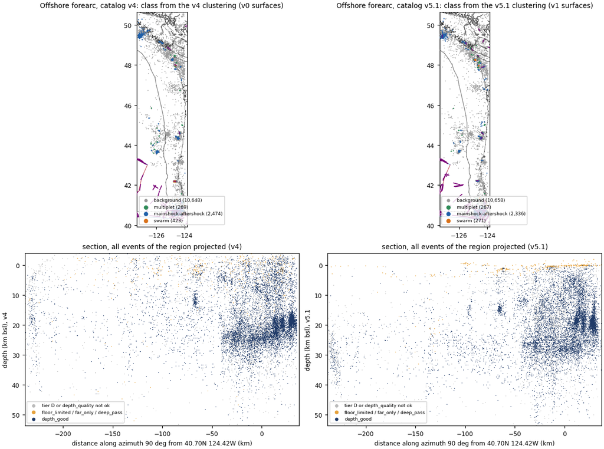

Offshore forearc: v4 and v5.1 maps and sections along 90°.

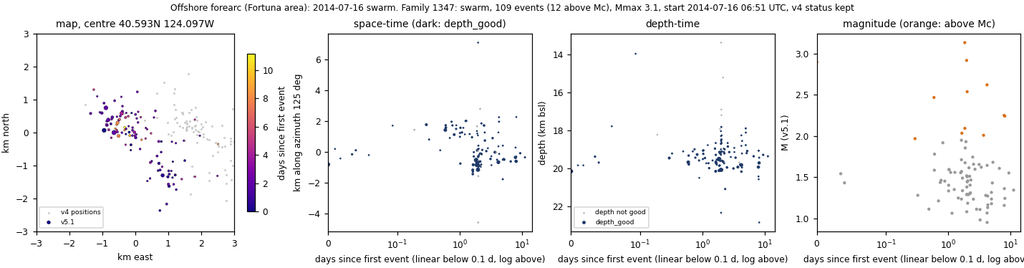

Fortuna-area swarm of 2014-07-16 (family 1347).

## Puget/Georgia

#### What the v5.1 locations change

14,854 rows, 14,833 located (21 without a hypocentre, left out), 411 flagged non-earthquakes. Tiers A/B/C/D: 15/26/36/22%. floor_limited 934, far_only 0, deep_pass 17; depth_good (tier A-C, depth_quality ok, no flag) 10,736. Median depth of located earthquakes: v4 14.6 km, v5.1 14.9 km bsl (15.0 km below the surface); median shift 2.1 km horizontally, +0.7 km in depth. Median sig_z 3.2 km, nearest station 16 km. In v4, 11% of these events plot above the ground or seafloor if v4 depth is read as km bsl.

Puget/Georgia is the control region: the median moved by +0.7 km. Central Puget Lowland crustal events (tier A-B, depth below 35 km) are at a median 19.5 km (p10-p90 12.8-25.2; v4 18.0) against 15-25 km with a mean of 17.6 km (Blakely et al. 2002; Van Wagoner et al. 2002). Against ANSS/ComCat (uw,us; fixed depths removed), on 4,261 events matched in both versions, our depth minus ANSS is -1.3 km in v4 and -0.3 km in v5.1 (median |difference| 2.7 and 2.6 km). 997 events are within 1 km of the surface and 68% of them fall on weekdays 08-17 local time (region: 29%); many are probably blasts that the ComCat match and the Texada rule did not flag. The daytime excess does not stop at 1 km (catalog problems, item 3): in Puget/Georgia and Other onshore together, about 1,130 of the 2,094 events within 1 km and about 2,470 events above 8 km are blast-like by their excess over the deeper weekday-daytime share.

#### Faults: which are active and how

The share of Puget events on a surface dropped most of any region (v0 61% of the fit set, v1 34%), because v0 kept flat seismicity layers (PU001, PU002) that the dip rule now removes in every pass. What remains is a set of moderately dipping zones: the Western Rainier Seismic Zone (v1_PU001, stable, J = 0.89), the Skipjack Island fault cluster (v1_ON006, stable, J = 0.93), the western Seattle fault zone (v1_PU002, stable but J = 0.45) and the Leech River fault zone (v1_PU006, J = 0.61). Candidates on the Tacoma fault (v1_PU005) and the SE end of the SWIF (v1_PU012) are not recovered on the subsample (J = 0.18 and 0.29). The question of whether crustal seismicity concentrates on the Seattle, Tacoma and SWIF zones therefore still needs the distance-to-CFM test against randomized catalogs; v1 adds only two robust surfaces near those faults.

**v1 surfaces with most members in this region**

| surface | events | strike | dip | depth km | depth ok | stable (reruns) | J 80% subsample | % bg | % swarm | v0 link | members dz v4->v5.1 | literature (carried from v0) | flags (faults piece, shortened) | notes added here |
| --- | --- | --- | --- | --- | --- | --- | --- | --- | --- | --- | --- | --- | --- | --- |
| v1_PU001 | 539 | 190.0 | 41.0 | 7.4 | 100.0 | True | 0.89 | 76.0 | 0.0 | split and merged | +1.4 | PU003: Western Rainier Seismic Zone \| PU022: Mount Rainier edifice VT seismicity | not recovered 2/3 |  |
| v1_ON006 | 506 | 290.0 | 41.0 | 14.8 | 100.0 | True | 0.93 | 53.0 | 13.0 | merged | +0.4 | ON010: Same cluster as ON011 \| ON011: Skipjack Island fault zone or a parallel strand; Bal | not recovered 1/3 |  |
| v1_PU002 | 414 | 214.0 | 77.0 | 17.7 | 100.0 | True | 0.45 | 62.0 | 16.0 | merged | +0.1 | PU012: Western SFZ (Bremerton–Hood Canal), Seattle–Saddle Mountain transfer zone \| PU013: | not recovered 3/3 |  |
| v1_PU004 | 310 | 277.0 | 47.0 | 16.1 | 100.0 | False | 0.23 | 44.0 | 23.0 | split and merged | -1.7 | PU002: East-dipping western edge of seismogenic Crescent basement (Crescent / Olympic subd | unstable; not recovered 3/3 |  |
| v1_PU005 | 266 | 332.0 | 33.0 | 14.7 | 100.0 | False | 0.18 | 76.0 | 0.0 | merged | +3.6 | PU018: Eastern continuation of the Tacoma fault / north-dipping roof thrust of the Seattle | unstable; not recovered 3/3 |  |
| v1_PU006 | 235 | 272.0 | 42.0 | 21.4 | 100.0 | False | 0.61 | 85.0 | 0.0 | matched | -0.5 | Leech River fault: NNE-dipping relocated seismic zone | unstable |  |
| v1_PU007 | 220 | 181.0 | 85.0 | 18.7 | 100.0 | False | 0.65 | 68.0 | 6.0 | split | +2.0 | Same as PU001 (parallel duplicate) | unstable; not recovered 2/3 |  |
| v1_PU008 | 178 | 188.0 | 37.0 | 7.2 | 100.0 | False | 0.13 | 96.0 | 0.0 | split and merged | +1.4 | PU003: Western Rainier Seismic Zone | unstable; not recovered 3/3 |  |
| v1_PU010 | 147 | 257.0 | 36.0 | 21.2 | 100.0 | False | 0.17 | 39.0 | 20.0 | split and merged | -1.1 | PU002: East-dipping western edge of seismogenic Crescent basement (Crescent / Olympic subd | unstable; not recovered 3/3 |  |
| v1_PU011 | 142 | 294.0 | 38.0 | 14.2 | 100.0 | False | 0.16 | 50.0 | 25.0 | matched | -0.8 | Diffuse mid-crustal Puget Lowland basement seismicity. SE end reaches the WRSZ | unstable; not recovered 3/3 |  |
| v1_PU012 | 115 | 232.0 | 80.0 | 18.0 | 100.0 | False | 0.29 | 72.0 | 0.0 | split | +0.8 | SE end of the SWIF in Seattle basin basement | unstable; not recovered 3/3 |  |
| v1_PU013 | 105 | 113.0 | 43.0 | 16.9 | 100.0 | False | 0.06 | 100.0 | 0.0 | matched | -0.3 | Hood Canal fault zone (northern reach) | unstable; not recovered 3/3 |  |
| v1_PU014 | 91 | 51.0 | 49.0 | 13.0 | 100.0 | False | 0.05 | 91.0 | 0.0 | matched | +4.0 | DDMFZ, Darrington–Oso section | unstable; not recovered 3/3 |  |
| v1_PU015 | 83 | 347.0 | 44.0 | 8.1 | 100.0 | False | 0.28 | 78.0 | 0.0 | matched | +5.4 | Rattlesnake Mountain fault zone (SWIF SE extension); 1996 Duvall source region | unstable; not recovered 3/3 |  |

#### Sequences, swarms and background

3,459 earthquakes above Mc: 79% background, 12% in mainshock-aftershock families, 4% in swarms, 5% in multiplets (v4: 80% / 12% / 4% for background / MA / swarm). Families of 5 or more above Mc led by an event here: mainshock-aftershock 14, swarms 12. Tier D events are 16% of the analysis set here, and 97% of them are background (tiers A-C: 76%). Among depth_good events above Mc, 93% of those at 30 km or deeper (intraslab, 472 depth_good events) are background, against 73% of the crustal ones, as in v4.

#### Swarm and sequence characteristics

Twelve swarms, all crustal (good-depth median 15 km), with long durations (median 9 days at the 90% level, 30 days in all) and small extents (median 1.7 km). The 2012-10-05 swarm (family 431, 59 events, 14-19 km) is on v1_PU002, the western Seattle fault zone surface. None migrates. Family 675 (2013-04-07, mainshock-aftershock, 52 events over 2.9 years, 7.6 km extent) passes the migration test (permutation p = 0.0005), but its radial speed is 0.004 km/day, about 4 km over the whole family: a slow drift of activity, not a resolved front.

**Largest families led by an event in this region**

| family | type | start (UTC) | events (>=Mc) | Mmax | t90 days | extent km | good-depth median km | n good | resolvable spread | migrating | on surfaces | main surface | nearest boundary | v4 status |
| --- | --- | --- | --- | --- | --- | --- | --- | --- | --- | --- | --- | --- | --- | --- |
| 1027 | mainshock-aftershock | 2013-12-06 05:26 | 205 (26) | 3.4 | 103.2 | 3.5 | 18.1 | 195 | False | False | 0.0 |  | SUB 247 km | kept |
| 2072 | mainshock-aftershock | 2016-07-01 18:36 | 73 (46) | 3.4 | 57.2 | 8.1 | 19.5 | 57 | False | False | 12.0 | v1_PU015 | SUB 324 km | kept |
| 431 | swarm | 2012-10-05 20:32 | 59 (22) | 2.7 | 81.7 | 3.2 | 16.9 | 55 | False | False | 86.0 | v1_PU002 | SUB 267 km | kept |
| 158 | mainshock-aftershock | 2011-02-08 16:36 | 54 (3) | 3.8 | 43.9 | 10.7 | 14.6 | 45 | True | False | 78.0 | v1_ON006 | SUB 257 km | kept |
| 675 | mainshock-aftershock | 2013-04-07 08:57 | 52 (14) | 3.4 | 202.3 | 7.6 | 23.2 | 49 | True | True | 90.0 | v1_PU010 | SUB 249 km | kept |
| 2006 | swarm | 2015-10-15 06:56 | 47 (14) | 2.7 | 0.8 | 1.7 | 18.9 | 38 | False | False | 81.0 | v1_PU010 | SUB 252 km | kept |

#### Against published studies

Agrees: crustal band and slab depths (Van Wagoner et al. 2002; Blakely et al. 2002; Preston et al. 2003); background-dominated intraslab seismicity.

#### v4-era interpretations that no longer hold

- v4/v0 'most Puget events on a fault' (61% of the fit set on v0 surfaces): v1 finds 34%; the v0 share included flat layers that are not faults.
- v4 'q10 depth of 1.1 km suggests quarry blasts': 411 flagged events are now removed, but blast-like events remain unflagged: about 1,100 in excess within 1 km of the surface in Puget/Georgia and Other onshore, and the excess continues to 5-8 km.

**Uncertainty.** Depths agree with the literature within about 2 km; unflagged blasts affect shallow statistics.

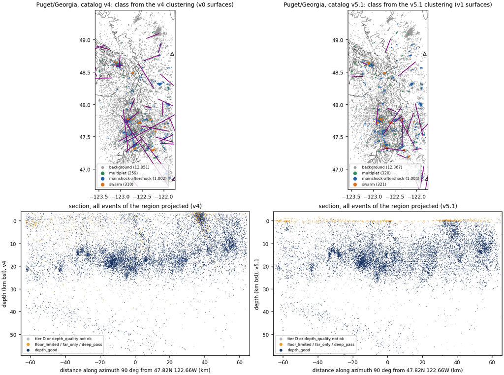

Puget/Georgia: v4 and v5.1 maps and sections along 90°.

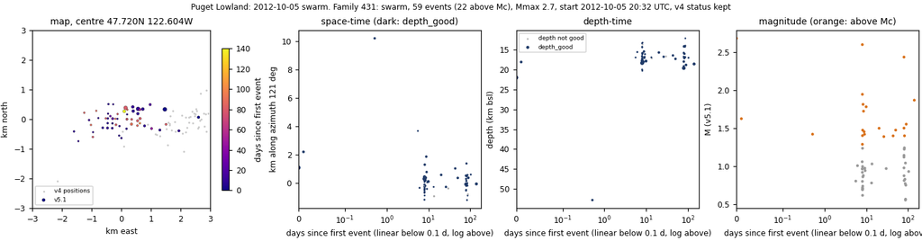

Puget Lowland swarm of 2012-10-05 (family 431).

## Cascades

#### What the v5.1 locations change

17,280 rows, 17,093 located (187 without a hypocentre, left out), 362 flagged non-earthquakes. Tiers A/B/C/D: 25/17/31/27%. floor_limited 1,358, far_only 0, deep_pass 178; depth_good (tier A-C, depth_quality ok, no flag) 11,650. Median depth of located earthquakes: v4 4.7 km, v5.1 7.1 km bsl (8.2 km below the surface); median shift 0.9 km horizontally, +1.7 km in depth. Median sig_z 2.5 km, nearest station 5 km. In v4, 17% of these events plot above the ground or seafloor if v4 depth is read as km bsl.

Mount Hood: 336 events within 15 km, none tier A-B, nearest station a median 54 km away (the stations closest to Hood may be missing from the station set; to check), so Hood depths are not usable.

#### Faults: which are active and how

v1 surfaces with most of their members here: 14 (12 steep, 7,802 fit members; v0: 16 surfaces, 6,337 members). Stable under the builder's detection reruns: 9; recovered on the verifier's 80% subsample: 6; on tiers A-B only: 1. Of the 16,731 located earthquakes in fitted boxes, 53% are fit members or assigned (loose), 3,249 are ambiguous and 4,619 are on no surface; 46% are on a surface by the strict rule (on_surface_strict). Median RMS scatter of members about their surface: v0 1.00 km, v1 1.22 km.

The St. Helens seismic zone is the best-imaged onshore structure: v1_ON001 (3,393 events, dip 47°, stable, J = 0.71; the dextral offset zone / east flank) and v1_ON002 (1,840 events, the SHZ main strand, strike 169°, dip 82°; 41% of its events above Mc in swarms, from the 2011 swarm). v1_ON010 and v1_ON013 keep their Mount Hood fault zone matches but rest on tier C/D depths. v1_ON016 (the recurring swarm source about 19 km north of Mount McLoughlin) is stable (J = 0.93) and the most swarm-dominated surface in the clustering piece's ranking (71% of its 42 events above Mc, strict join). v1_ON028 (42 events at 23-38 km under Mount St. Helens) contains P1 deep events; the faults piece flags it as not usable until the review is done.

**v1 surfaces with most members in this region**

| surface | events | strike | dip | depth km | depth ok | stable (reruns) | J 80% subsample | % bg | % swarm | v0 link | members dz v4->v5.1 | literature (carried from v0) | flags (faults piece, shortened) | notes added here |
| --- | --- | --- | --- | --- | --- | --- | --- | --- | --- | --- | --- | --- | --- | --- |
| v1_ON001 | 3393 | 302.0 | 47.0 | 5.0 | 100.0 | True | 0.71 | 83.0 | 0.0 | matched | +1.6 | Mount St. Helens dextral offset zone (local extension) / east-flank volcanic seismicity | above surface; not recovered 1/3 |  |
| v1_ON002 | 1840 | 169.0 | 82.0 | 5.8 | 100.0 | False | 0.37 | 48.0 | 41.0 | split | +1.8 | St. Helens seismic zone (SHZ), main strand | unstable; not recovered 3/3 |  |
| v1_ON003 | 770 | 119.0 | 60.0 | 9.6 | 100.0 | False | 0.41 | 37.0 | 23.0 | merged | +1.4 | ON017: SHZ segment south of the volcano \| ON016: MSH east flank, overlapping ON006 | unstable; not recovered 3/3 |  |
| v1_ON004 | 678 | 311.0 | 60.0 | 14.4 | 100.0 | False | 0.27 | 71.0 | 0.0 | matched | +1.5 | Northern end of the SHZ / ENE stepover to the western Rainier zone at 12–20 km | unstable; not recovered 3/3 |  |
| v1_PU003 | 381 | 337.0 | 45.0 | 9.4 | 100.0 | False | 0.72 | 83.0 | 0.0 | split and merged | +1.8 | PU003: Western Rainier Seismic Zone \| ON018: Goat Rocks zone (GRZ), NNW alignment north of | unstable; not recovered 2/3 |  |
| v1_ON010 | 158 | 355.0 | 65.0 | 10.2 | 100.0 | True | 0.33 | 23.0 | 54.0 | matched | +5.4 | Mount Hood fault zone, Twin Lakes segment | not recovered 2/2 |  |
| v1_PU009 | 157 | 232.0 | 89.0 | 11.6 | 100.0 | True | 0.91 | 32.0 | 30.0 | matched | +6.8 | No known counterpart, probably several clusters chained together | not recovered 1/2 |  |
| v1_ON013 | 111 | 114.0 | 49.0 | 10.1 | 100.0 | True | 0.35 | 54.0 | 12.0 | matched | +5.8 | Mount Hood south-flank swarm zone (Twin Lakes / Multorpor graben) | not recovered 2/2 |  |
| v1_ON016 | 89 | 56.0 | 83.0 | 10.2 | 100.0 | True | 0.93 | 10.0 | 71.0 | matched | +0.7 | Recurring swarms about 19 km N of Mount McLoughlin (east of Butte Falls) |  |  |
| v1_ON018 | 71 | 118.0 | 60.0 | 17.3 | 100.0 | True | 0.98 | 74.0 | 0.0 | new | -2.0 |  | not recovered 2/3 |  |
| v1_ON022 | 50 | 137.0 | 41.0 | 13.2 | 100.0 | True | 0.86 | 88.0 | 0.0 | new | +1.6 |  | not recovered 2/3 |  |
| v1_ON028 | 42 | 266.0 | 45.0 | 29.3 | 100.0 | False | 0.46 | 25.0 | 50.0 | new | +2.3 |  | MSH deep (review P1); unstable; not recovered 3/3 | members include Mount St Helens deep events (waveform review P1: likely false events from a weekly artificial signal on analog UW channels) |
| v1_ON032 | 32 | 343.0 | 74.0 | 5.5 | 100.0 | True | 0.00 | 10.0 | 80.0 | matched | -0.5 | Oct 2015 swarm at the Davis Lake volcanic complex (SW of La Pine) | not recovered 2/2 |  |
| v1_ON033 | 30 | 252.0 | 86.0 | 12.4 | 100.0 | True | 0.00 | 56.0 | 0.0 | new | -0.4 |  | not recovered 3/3 |  |

#### Sequences, swarms and background

1,901 earthquakes above Mc: 66% background, 9% in mainshock-aftershock families, 14% in swarms, 12% in multiplets (v4: 64% / 11% / 14% for background / MA / swarm). Families of 5 or more above Mc led by an event here: mainshock-aftershock 8, swarms 22. Tier D events are 28% of the analysis set here, and 73% of them are background (tiers A-C: 63%). At Mount St. Helens (within 15 km) 436 events are above the regional Mc and 49% are background; with a local Mc the clustering piece finds 269 families (v4 308), none meeting two swarm indicators; time-shuffled catalogs are less bimodal but not by much (Ashman D median 1.71, maximum 1.83 over 10 shuffles, against 2.27). 212 of the 3,593 events above the local Mc are P1 deep events (101 in families). In the regional run, 159 of the 331 P1 deep events are above Mc and 77 are in 32 families; 10 of those families start on a Wednesday between 11:57 and 12:18 Pacific time. The volcano clustering is therefore not a basis for a swarm/burst statement, as in v4.

#### Swarm and sequence characteristics

Twenty-two swarms, 17 within 25 km of a volcano. The 2011-01-28 Mount St. Helens swarm (family 150, 358 events, 20 above Mc, Mmax 3.9) lies on v1_ON002, 10 km north of the summit, at 4.1-5.7 km bsl, lasted a year in all with most activity in February 2011, and does not migrate. Family 830 (2013-08-03 to 2014-01-29, 338 events, 166 tier A) is a compact source 21 km NW of the summit, 1.1 km across and at 13.1-14.6 km depth, active for six months; v4 had it at 13 km too. It is a deep, well-located persistent cluster in the SHZ; its timing (136 of 338 events on one Saturday) and tier A locations point to a real swarm, not to the Wednesday signal.

**Largest families led by an event in this region**

| family | type | start (UTC) | events (>=Mc) | Mmax | t90 days | extent km | good-depth median km | n good | resolvable spread | migrating | on surfaces | main surface | nearest boundary | v4 status |
| --- | --- | --- | --- | --- | --- | --- | --- | --- | --- | --- | --- | --- | --- | --- |
| 150 | swarm | 2011-01-28 00:44 | 358 (20) | 3.9 | 18.2 | 21.4 | 5.0 | 332 | False | False | 91.0 | v1_ON002 | SUB 269 km | kept |
| 830 | swarm | 2013-08-03 02:11 | 338 (23) | 3.5 | 98.3 | 1.1 | 13.9 | 329 | False | False | 0.0 |  | SUB 256 km | kept |
| 659 | swarm | 2013-03-24 08:00 | 45 (15) | 3.2 | 18.4 | 1.9 | 11.9 | 44 | False | False | 93.0 | v1_ON016 | SUB 231 km | kept |
| 2067 | swarm | 2016-05-16 12:19 | 35 (8) | 2.4 | 1.8 | 1.3 | 6.2 | 25 | False | False | 60.0 | v1_ON010 | SUB 292 km | kept |
| 534 | swarm | 2012-12-15 05:44 | 33 (28) | 2.1 | 45.0 | 4.3 | 11.4 | 32 | False | False | 94.0 | v1_PU009 | SUB 338 km | merged |
| 2011 | swarm | 2015-10-22 10:13 | 28 (16) | 3.1 | 4.9 | 7.3 | 6.4 | 24 | False | False | 82.0 | v1_ON032 | SUB 292 km | kept |

#### Against published studies

Agrees: Mount St. Helens depths (Hirao et al. 2025, +0.5 to +0.8 km); SHZ geometry. Disagrees: the 30-118 km population under the volcano. Not testable: Hood, Shasta, Lassen depths (tier C/D, distant stations).

#### v4-era interpretations that no longer hold

- v4 Cascades median depth 4.7 km: v5.1 7.1 km, partly from the deep population (659 events deeper than 30 km) that should not be interpreted.
- v0 Mount Hood fault-zone surfaces: traces only; depths rest on tier C/D events.

**Uncertainty.** Exclude events deeper than 30 km within 15 km of Mount St. Helens (review P1) and the onshore deep-pass events (review P4) until the human review is done.

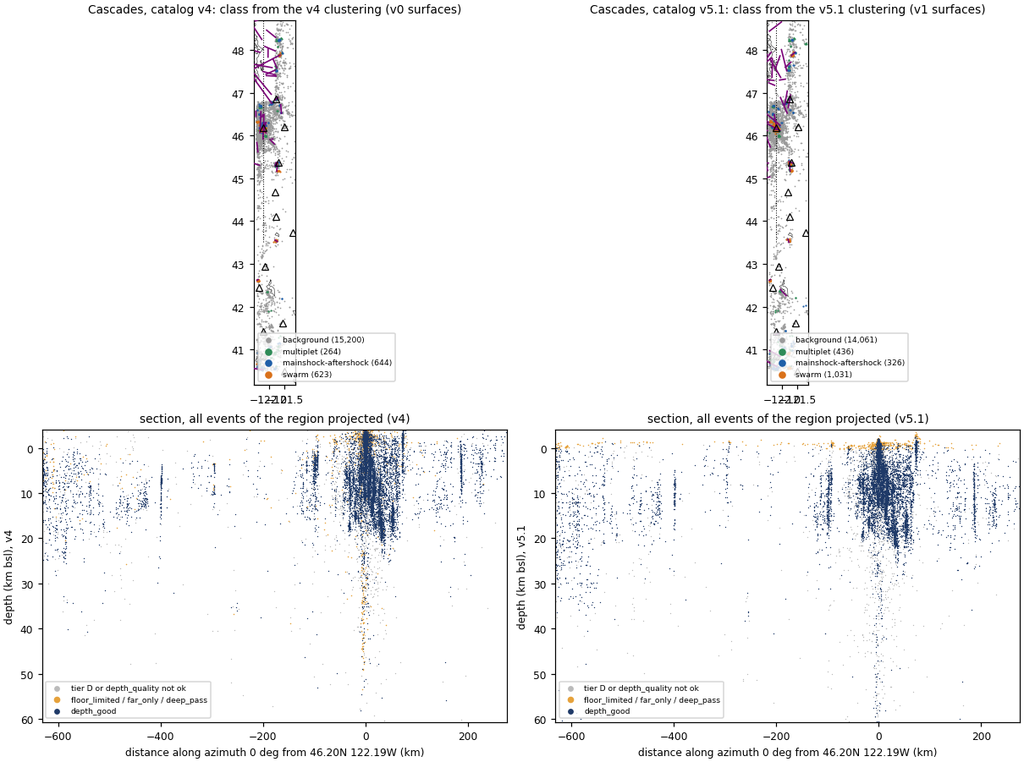

Cascades: v4 and v5.1 maps and sections along 0° (north-south).

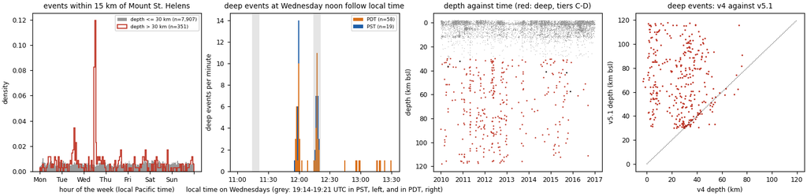

Mount St. Helens: hour of the week (local Pacific time) of events deeper and shallower than 30 km; deep events on Wednesdays 11:00-13:30 local by minute, PDT and PST stacked (grey: 19:14-19:21 UTC, which falls at 11:14 local in PST and 12:14 in PDT); depth against time; v4 against v5.1 depth of the deep events.

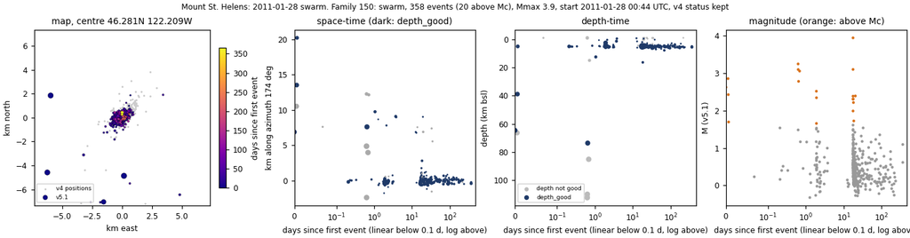

Mount St. Helens swarm of 2011-01-28 (family 150).

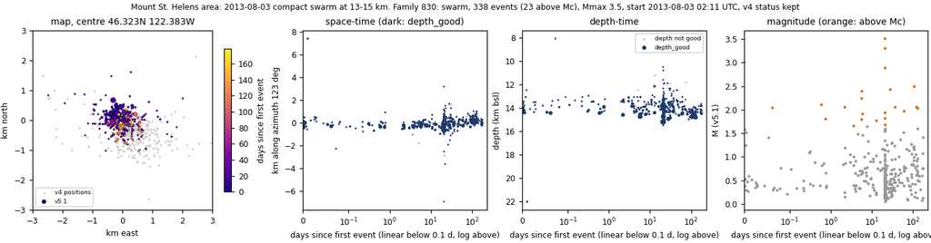

Compact SHZ swarm of 2013-08-03 (family 830).

## Other onshore

#### What the v5.1 locations change

15,093 rows, 14,825 located (268 without a hypocentre, left out), 956 flagged non-earthquakes. Tiers A/B/C/D: 18/21/35/27%. floor_limited 1,277, far_only 9, deep_pass 41; depth_good (tier A-C, depth_quality ok, no flag) 9,617. Median depth of located earthquakes: v4 14.5 km, v5.1 16.3 km bsl (16.8 km below the surface); median shift 1.8 km horizontally, +2.0 km in depth. Median sig_z 3.6 km, nearest station 19 km. In v4, 8% of these events plot above the ground or seafloor if v4 depth is read as km bsl.

Against ANSS/ComCat (uw,nc,us; fixed depths removed), on 2,946 events matched in both versions, our depth minus ANSS is -1.6 km in v4 and +0.5 km in v5.1 (median |difference| 2.9 and 2.4 km). The depth-literature checks still apply: Oregon and SW Washington within about 0.2 km of PNSN, the Scotts Mills area near the 13-15 km mainshock depth, and the northern California slab 2-3 km deeper than NCSN (the Mendocino offset). 1,097 events are within 1 km of the surface and 61% of them are on weekdays 08-17 local time (region: 31%), so many are probably unflagged blasts; the excess continues below 1 km (catalog problems, item 3). 41 events come from the deep pass (39 tier D; waveform review P4).

#### Faults: which are active and how

v1 surfaces with most of their members here: 21 (15 steep, 2,583 fit members; v0: 21 surfaces, 3,000 members). Stable under the builder's detection reruns: 9; recovered on the verifier's 80% subsample: 6; on tiers A-B only: 3. Of the 13,869 located earthquakes in fitted boxes, 37% are fit members or assigned (loose), 693 are ambiguous and 7,809 are on no surface; 27% are on a surface by the strict rule (on_surface_strict). Median RMS scatter of members about their surface: v0 1.14 km, v1 1.21 km.

The stable, recovered surfaces are small and local: the 2015-07-04 Springfield earthquake fault (v1_ON009, J = 0.97), the Salmon Inlet site of the 2025 Mw 4.8 earthquake (v1_ON014, J = 0.93) and its companion (v1_ON012, J = 1.00). The southern continuation of the SHZ toward Portland (v1_ON005, v1_ON007) and the Portland Hills fault candidate (v1_ON008, dip 32°, J = 0.70) are 63-83% background (8-36 events above Mc each).

**v1 surfaces with most members in this region**

| surface | events | strike | dip | depth km | depth ok | stable (reruns) | J 80% subsample | % bg | % swarm | v0 link | members dz v4->v5.1 | literature (carried from v0) | flags (faults piece, shortened) | notes added here |
| --- | --- | --- | --- | --- | --- | --- | --- | --- | --- | --- | --- | --- | --- | --- |
| v1_ON005 | 601 | 148.0 | 63.0 | 15.1 | 100.0 | False | 0.46 | 77.0 | 0.0 | split | +1.3 | St. Helens seismic zone (SHZ), main strand | unstable; not recovered 3/3 |  |
| v1_ON007 | 403 | 160.0 | 33.0 | 15.2 | 100.0 | False | 0.38 | 62.0 | 0.0 | merged | +0.9 | ON004: Southern continuation of the SHZ toward Portland / the NE-trending SHZ–Portland zon | unstable; not recovered 2/3 |  |
| v1_ON008 | 255 | 162.0 | 32.0 | 17.4 | 100.0 | False | 0.70 | 83.0 | 0.0 | merged | +2.4 | ON013: Portland Hills fault (north) / Sylvan–Oatfield, deep part \| ON025: Portland Hills / | unstable; not recovered 1/3 |  |
| v1_ON009 | 183 | 137.0 | 66.0 | 7.3 | 100.0 | True | 0.97 | 52.0 | 0.0 | matched | +0.2 | 2015-07-04 Springfield earthquake (ComCat M4.1; SLU Mw 3.75); no mapped Quaternary fault | not recovered 2/3 |  |
| v1_ON011 | 137 | 257.0 | 77.0 | 14.8 | 100.0 | True | 0.00 | 86.0 | 0.0 | new | +1.9 |  | not recovered 2/3 |  |
| v1_ON012 | 127 | 167.0 | 60.0 | 13.5 | 100.0 | True | 1.00 | 100.0 | 0.0 | matched | +2.2 | Possible companion of ON014 (same strike, 10 km north) | above surface; not recovered 2/3 |  |
| v1_ON014 | 108 | 268.0 | 63.0 | 13.3 | 100.0 | True | 0.93 | 30.0 | 0.0 | matched | +1.8 | Site of the 2025-02-21 Salmon Inlet earthquake (Mww 4.8, ComCat 49.693°N, 123.545°W); no m | not recovered 1/3 |  |
| v1_ON015 | 92 | 168.0 | 80.0 | 15.1 | 100.0 | True | 0.00 | 100.0 | 0.0 | split and merged | +1.5 | ON024: none (Sweet Home–Lebanon foothills) \| ON035: none (Lebanon–Scio) | not recovered 2/3 |  |
| v1_MT026 | 81 | 16.0 | 38.0 | 7.5 | 100.0 | False | 0.18 | 97.0 | 0.0 | new | +7.8 |  | above surface; unstable; not recovered 2/2 |  |
| v1_ON019 | 71 | 118.0 | 33.0 | 22.1 | 100.0 | False | 0.43 | 58.0 | 18.0 | matched | +3.5 | Deep crustal seismicity beneath Redding / Keswick (outside the target region) | unstable; not recovered 3/3 |  |
| v1_MT029 | 64 | 150.0 | 60.0 | 21.9 | 100.0 | True | 0.00 | 86.0 | 0.0 | matched | +3.3 | Upper plate beneath Blue Lake–Korbel. Weak similarity to McKinleyville / Mad River, but op | not recovered 3/3 |  |
| v1_ON020 | 55 | 327.0 | 32.0 | 11.3 | 100.0 | False | 0.00 | 100.0 | 0.0 | split and merged | +1.0 | ON024: none (Sweet Home–Lebanon foothills) | unstable; not recovered 3/3 |  |
| v1_WA002 | 55 | 2.0 | 79.0 | 22.3 | 100.0 | False | 0.00 | 100.0 | 0.0 | split | +0.0 | Secondary structure within the LRF seismic zone / Saanich–Malahat area | unstable; not recovered 3/3 |  |
| v1_ON021 | 52 | 31.0 | 49.0 | 6.3 | 100.0 | True | 0.86 | 76.0 | 0.0 | new | +6.9 |  | not recovered 1/3 |  |

#### Sequences, swarms and background

2,748 earthquakes above Mc: 84% background, 9% in mainshock-aftershock families, 2% in swarms, 5% in multiplets (v4: 84% / 10% / 1% for background / MA / swarm). Families of 5 or more above Mc led by an event here: mainshock-aftershock 6, swarms 9. Tier D events are 33% of the analysis set here, and 88% of them are background (tiers A-C: 82%).

#### Swarm and sequence characteristics

Nine small swarms (median 7 events, median t90 1.2 days); none migrates.

**Largest families led by an event in this region**

| family | type | start (UTC) | events (>=Mc) | Mmax | t90 days | extent km | good-depth median km | n good | resolvable spread | migrating | on surfaces | main surface | nearest boundary | v4 status |
| --- | --- | --- | --- | --- | --- | --- | --- | --- | --- | --- | --- | --- | --- | --- |
| 1619 | mainshock-aftershock | 2015-02-15 04:12 | 48 (9) | 3.6 | 18.6 | 2.6 | 13.7 | 45 | False | False | 90.0 | v1_ON014 | SUB 280 km | kept |
| 119 | mainshock-aftershock | 2010-11-16 15:51 | 41 (2) | 4.0 | 0.4 | 9.4 | 14.5 | 38 | False | False | 93.0 | v1_ON004 | SUB 256 km | kept |
| 301 | mainshock-aftershock | 2012-02-13 21:07 | 40 (17) | 5.6 | 61.2 | 9.0 | 29.8 | 39 | True | False | 88.0 | v1_MT031 | SUB 102 km | kept |
| 110 | mainshock-aftershock | 2010-10-18 15:21 | 28 (4) | 4.0 | 2.7 | 2.7 | 20.0 | 19 | False | False | 0.0 |  | CCB 72 km | kept |
| 1094 | mainshock-aftershock | 2014-01-26 16:43 | 26 (4) | 2.6 | 21.5 | 0.5 | 18.4 | 23 | False | False | 0.0 |  | SUB 215 km | kept |
| 390 | mainshock-aftershock | 2012-08-24 14:04 | 26 (4) | 3.4 | 5.4 | 0.4 | 24.9 | 25 | False | False | 77.0 | v1_PU006 | SUB 220 km | kept |

#### Against published studies

Agrees with PNSN and the Oregon benchmarks; northern California slab +2-3 km against NCSN, inside the broad published ranges.

#### v4-era interpretations that no longer hold

- No v4 interpretation specific to this region is overturned; the near-surface population is still contaminated by blasts.

**Uncertainty.** Coast Ranges south of 40°N and distant volcanoes: tier C/D only.

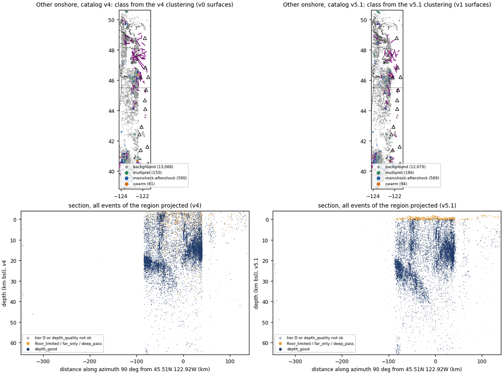

Other onshore: v4 and v5.1 maps and sections along 90°.

## Catalog problems found in this interpretation

1. **Deep events under Mount St. Helens (waveform review P1).** 351 events within 15 km of the summit are deeper than 30 km (tiers D 224, C 122, B 4, A 1; median sig_z 17 km with the nearest station 5 km away); the review's box (46.05-46.30°N, 122.35-122.10°W) holds 331. v4 had them at a median 29 km, v5.1 at 67 km. The review (/wd1/mdenolle_data/catalog_v5/v5.1_review/P1_msh_deep/) found that the analog UW channels HSR, EDM and STD.UW carry a weekly artificial signal on Wednesdays at 19:14-19:21 UTC from 2011-05 to 2013-08, and that the deep events are 96% UW P picks, 80% have all their P picks within 0.5 s and 73% have no S pick: likely false events, pending human review.  
   The timing is local, not UTC. On Wednesdays the deep events cluster at about 11:55-12:00 and 12:13-12:20 Pacific time (34 between 11:50 and 12:05, 31 between 12:10 and 12:25), in standard and daylight time alike: 71 deep events on 51 Wednesdays between 11:30 and 13:00 local (19 in PST, 52 in PDT; 2011-06-08 to 2013, one in 2015), against 10 on Tuesdays at the same hours. The 19:14-19:21 UTC window holds 22 of them: the daylight-time half of the 12:13-12:20 cluster. The review's continuous-data scan covered 19:05-19:30 UTC only, and its 19:14-19:21 detections are all on daylight-time Wednesdays (STD.UW 50 of 89, HSR.UW 42 of 89; 0 of 36 standard-time Wednesdays at either station, 2011-05 to 2013-09), where the same local time falls at 20:14-20:21 UTC, outside the scan. Together these say that the signal is set by local time (about 12:14-12:21 Pacific), so a flag rule must use local time, and the review's UTC scan should be extended to 20:00-20:30 UTC in standard time to confirm it. The weekly window does not explain the deep population as a whole: 280 of the 351 deep events fall outside the Wednesday 11:30-13:00 local window. In the clustering, 159 of the 331 P1 deep events are above Mc and 77 are in 32 families, 10 of which start on a Wednesday between 11:57 and 12:18 Pacific time.
2. **Depth spikes at integer km, not at model nodes.** The first build reported pile-ups at the depth nodes of model v0.3.1 (Axial 3 km, Blanco 12 and 15 km, Gorda 29 km). Its metric (events within 0.25 km against the 0.25-1.25 km flanks) measured the peak of the depth mode. A local spike test (events within 0.1 km of a depth against the mean of the two bins 0.3 km either side) on integer depths 1-40 km, split into model nodes and other integers, with half-integers as controls:

   | region | median ratio at model nodes | median ratio at other integers | median ratio at half-integers | integer depths with ratio >= 2 (* model node) |
   | --- | --- | --- | --- | --- |
   | Axial | 1.15 | 0.98 | 1.04 | 2 (2.1) |
   | Blanco | 1.63 | 1.43 | 1.00 | 12* (6.8), 15* (3.5), 16 (3.0), 17 (2.1), 18* (2.5), 19 (3.3), 20 (2.3) |
   | Gorda | 1.57 | 1.40 | 0.98 | 9* (2.1), 12* (2.0), 20 (2.0), 29* (3.3), 30 (3.0), 37 (2.3) |
   | Mendocino | 1.15 | 1.08 | 1.00 | 1* (2.1), 37 (2.4) |
   | Offshore forearc | 1.29 | 1.30 | 0.95 | 1* (3.6), 6 (2.0), 29* (2.2), 30 (2.6) |
   | Puget/Georgia | 1.39 | 1.32 | 1.02 | none |
   | Other onshore | 1.27 | 1.18 | 1.01 | 36 (2.2) |
   | Cascades | 1.24 | 1.22 | 0.96 | none |

   Half-integers give median ratios of 0.95-1.04, other integers 0.98-1.43 and model nodes 1.15-1.63: the effect is at integer km in general, at most slightly stronger at nodes (Blanco, Gorda). The Blanco peaks sit in the 0.05 km bins 11.95-12.00, 14.95-15.00 and 18.95-19.00 km, where the Earth-flattening transform puts integer depth nodes of the NonLinLoc grids; the likely cause is the 1 km lattice of the travel-time grids, not the linear interpolation of the model. Only the Blanco 12 km spike (ratio 6.8) stands out at a model node. Axial has no spike at its 3 km node (1.07; 1.06 at 3.5 km): the first build's statement that part of the Axial 81% within 2 km of the seafloor is set by the model grid is withdrawn.

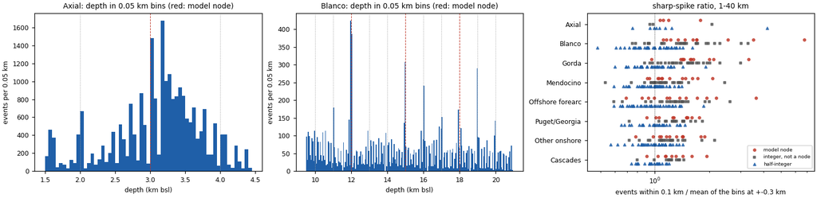

   Depth spikes. Left and middle: 0.05 km depth histograms at Axial and on the Blanco (red dashed: model v0.3.1 node; grey dotted: other integer). Right: sharp-spike ratio at model nodes, other integers and half-integers, by region.

3. **Blast-like onshore events.** In Puget/Georgia and Other onshore, 2,094 events lie within 1 km of the surface and 65% of them fall on weekdays 08-17 local time, against 23% for events more than 12 km below the surface. The excess does not stop at 1 km: the weekday-daytime share is 0.59, 0.61, 0.56 and 0.42 at 1-2, 2-3, 3-5 and 5-8 km below the surface, and 0.21-0.24 below 12 km. Sized by its excess over the deep share, the blast-like population is about 1,130 of the 2,094 events within 1 km and about 2,470 events above 8 km in all; the other events within 1 km look like ordinary seismicity. 83% of the events within 1 km are already floor_limited, so their depths are not measured anyway. A flag that cuts at 1 km would miss more than half of the excess and remove about 960 ordinary events; a flag needs a source criterion (known quarries, waveform discrimination, ComCat explosion matches), not a depth cut. The Cascades show no such excess (28% within 1 km against 26% regionally).
4. **Brookings 2012 swarm (v1_GO022; waveform review P2).** 39 events at a median 52 km (v4 20 km) with depth_quality ok. Slab2 puts the slab top at about 10 km (9.4-11.4 km at the members' epicentres; 8.3-12.9 km over the nearby nodes), so v5.1 is about 42 km below it and v4 was already about 9 km below it. The review (/wd1/mdenolle_data/catalog_v5/v5.1_review/P2_brookings/) shows why: predicted S-P is not monotonic with depth in the v5.1 grids, so about 7-9 km and about 56 km both fit the distant stations, and NonLinLoc took the deep one. v1_ON017 off Vancouver Island moved +15 km.
5. **Onshore deep-pass events (waveform review P4)**: 236 events in Cascades, Other onshore and Puget/Georgia at a median 91 km, mostly tier D. The slab is at 40-80 km under the arc. The review's P4 set has 356 deep-pass events (median 86 km) and 624 far_only events (median 52 km; far_only events moved from near the surface in v4 to 44-64 km).
6. **Explorer depths** are a median 44 km seaward (v4 9 km); ComCat tensor events there are 25 km deeper than ComCat (+13.7 km over all tensor events, review P3). The depth-quality flag ("unconstrained") is right, but the column invites misuse; consider not publishing depths there.

## v4-era interpretations revisited

| region | v4-era statement and its status in v5.1 |
| --- | --- |
| Axial | v4 'second cluster at 4-5 km' (science report): not in v5.1; those events are at the same depth as the rest. |
| Axial | v4 'lowest background share and most swarms per event' (v4 clusters): the split moves from 38% to 82% background with the variant, and shuffled catalogs reproduce 75% of the links; it is not a setting… |
| Axial | v4 western lobe at 130.06°W: moved 3 km east onto the caldera wall. |
| Endeavour | v4 'median QC depth 12.4 km, deep for a ridge' (science report): v5.1 does not resolve it either; half the events are deeper than 8 km below the seafloor and a quarter are pinned at it. |
| Endeavour | v4 Endeavour surfaces (EN001-EN004) as fault planes: their depths and dips are not usable (0% depth_quality ok). |
| Explorer | v4 Explorer depths (median 9 km) were closer to the literature than v5.1 (40 km); neither is a constraint. |
| Explorer | v4/v0 Explorer surfaces as dipping faults at depth: not usable; only traces. |
| Explorer | v4 2012-02-04 and 2012-11 Explorer sequences 'expand at 0.2-1.2 km/day': the 2012-11 sequence no longer passes the test; the 2012-02-04 one passes because a second cluster 15 km NNE started 9-12 days … |
| JdF ridge/plate | v4 depths of the 2013-2014 ridge swarms (12-16 km): not supported; v5.1 pins them at the seafloor, which is not a measurement either. |
| Blanco | v0 Blanco 'deeper band' (merged strands): reappears as v1_BL009/BL015 on events with unconstrained depth; still not a fault. |
| Blanco | v0 Cascadia Depression N-S faults: not recovered in v1 because of detection order; the v0 interpretation is neither confirmed nor refuted by v1. |
| Blanco | v4 2014-03-11 mainshock-aftershock family (1,274 events): now a 480-event swarm; family membership at Blanco depends on epicentre precision. |
| Blanco | v4 'vertical columns where depth is poorly constrained': still present, now deeper on the Blanco Ridge, plus spikes at integer depths (1 km grid lattice; strongest at 12 km). |
| Gorda | v4 'Gorda plate median depth 21.5 km' and slab-versus-plate questions based on it: the bulk of that depth is a station-distance bias; near-station events are at 8-11 km below the seafloor. |
| Gorda | v4 2013-05-20 Escanaba swarm 'migrates at about 10 km/day': not supported in v5.1. |
| Gorda | v4 '65% of families are swarms': 48% in v5.1 (25 families). |
| Mendocino | v4 depths closer to NCSN (+1.5 km) than v5.1 (+3.6 km): the relocation increased the Mendocino offset; slab-crust versus slab-mantle statements wait on it. |
| Mendocino | v4 2010 Mw 6.5 family with the Mw 5.9 aftershock: in v5.1 the Mw 5.9 heads its own family; membership near the threshold is not stable. |
| Offshore forearc | v0 GO020 'Brookings swarm, candidate new structure at about 12 km': v5.1 puts it at 42-65 km because NonLinLoc took the deeper of two S-P solutions (review P2); a solution near 7-9 km fits the distant… |
| Offshore forearc | v4 'offshore Oregon 10th-percentile depth 0.0 km' (fixed depths): gone in v5.1 (p10 6 km); 442 forearc events are floor_limited instead. |
| Puget/Georgia | v4/v0 'most Puget events on a fault' (61% of the fit set on v0 surfaces): v1 finds 34%; the v0 share included flat layers that are not faults. |
| Puget/Georgia | v4 'q10 depth of 1.1 km suggests quarry blasts': 411 flagged events are now removed, but blast-like events remain unflagged: about 1,100 in excess within 1 km of the surface in Puget/Georgia and Other… |
| Cascades | v4 Cascades median depth 4.7 km: v5.1 7.1 km, partly from the deep population (659 events deeper than 30 km) that should not be interpreted. |
| Cascades | v0 Mount Hood fault-zone surfaces: traces only; depths rest on tier C/D events. |
| Other onshore | No v4 interpretation specific to this region is overturned; the near-surface population is still contaminated by blasts. |

Interpretations that still hold: the Axial rate history and the eruption swarm; the swarm-rich West Blanco Depression and the swarm character of the large Blanco multiplets; the low-productivity, burst-like Mendocino triple junction; the background-dominated forearc and Puget intraslab seismicity; the Explorer 2012-02 sequence as a map-view two-patch sequence; the Fortuna cluster depth; the St. Helens seismic zone geometry and the shallow Mount St. Helens depths; the Puget crustal band.

## Proposed decisions (for the main session)

1. Report depths only where they pass a benchmark here: Axial tiers A-B, Mount St. Helens shallow events, Puget/Georgia, Oregon/SW Washington onshore, the Fortuna cluster, and Gorda/Blanco events with a station within 10-15 km. Elsewhere publish epicentres and flag depth.
2. Treat the Axial background/clustered share as a range (38-82%) and do not use Axial in the heat-flow ordering of clustering styles. Quote clustering ratios per box (no West Blanco Depression null test exists).
3. Call a v1 surface robust only when it is stable under the builder's reruns and recovered on the verifier's 80% subsample (J >= 0.5); quote the others as candidates; do not read detection robustness as depth validation (v1_GO022, v1_ON017). Keep the v0 Cascadia Depression N-S faults until a Cascadia-Depression-only fit is run.
4. Do not report swarm diffusivities or migration speeds from v5.1 absolute locations: of 67 resolvable families, 4 pass the permutation test against about 0.7 by chance, 2 survive a Bonferroni correction and neither is a resolved front. Describe the Explorer 2012-02 sequence as a two-patch sequence. Relocate swarms relatively (double difference) before any migration or diffusion analysis.
5. Next catalog version (v6.0): flag the Mount St. Helens deep population after the P1 review, with a rule in local time (Wednesdays about 11:50-12:25 Pacific) plus the review's common-mode rule (P picks at UW stations, P-pick spread under 0.5 s, no S); flag blast-like onshore events by source, not by a 1 km depth cut; flag onshore deep-pass and far_only events after the P4 review; take the shallow S-P solution for Brookings into account (P2). Check whether the integer-km depth spikes survive in v6.0 (they point to the 1 km grid lattice).
6. Decide whether phase19 is run to convergence (magnitude piece) before any offshore Mc, b or magnitude statement is published.

## Method notes

Tables and figures: `v51_interp_tables.py`, `v51_interp_figs.py`, report `v51_interp_report.py`. The joined event table (catalog + v5.1 M + cluster class + fault assignment + nearest PB2002 step) is on /wd1 (`v5.1_analysis/interp/events_joined.pkl`). Nearest-neighbour sharpness uses the same depth_good events in both versions, local km projection, depth in km. ANSS matches: 3 s and 20 km from our origin of each version (a second rule drops every round ANSS depth). Depth spikes: events within 0.1 km of a depth against the mean of the two equal bins centred 0.3 km either side, at integer km (model nodes and other integers) and at half-integers as controls (t8_depth_spikes.csv). Mount St. Helens timing: local time is America/Los_Angeles with daylight saving. Blast-like population: weekday 08:00-16:59 local share by depth below the surface, excess over the share of events more than 12 km below the surface. Benchmark boxes are defined in `t7_benchmarks` of the tables script; literature values are those of the depth-literature report. PB2002 steps (Bird 2003) give the nearest ridge/transform/subduction step. Families, swarm types and migration statistics are those of the clustering piece; surface statistics and literature matches those of the faults piece, with the verifiers' recovery Jaccard, the faults piece's own flags (flt_flags, shortened in flt_flags_short) and the notes added here (surfaces_v1_interp.csv, column interp_flags).